# Match day 11 Season 2627

Result

| Liverpool Szoboszlai 10' Wirtz 13' Ngumoha 66' Muñoz 82' | 4 – 0 | Man Utd — |
| --- | --- | --- |

Liverpool vs Man Utd - 22-11-2026 | Premier League MD 11

Liverpool beat Man Utd 4–0 with the better of the xG (4.37 vs 0.65). Liverpool's peak field tilt was 93% in the 3rd Quarter. Man Utd's peak field tilt was 29% in the 1st Quarter.

xG

LIV 4.37 – 0.65 MAN

xGOT

LIV 3.69 – 0.32 MAN

Field Tilt %

LIV 84% – 16% MAN

PPDA (lower = more intense press)

LIV 8.77 – 24.25 MAN

EPV

LIV 4.12 – 1.15 MAN

EPV to xG Conversion %

LIV 106% – 57% MAN

xG Race

[figure not shown]

Match Momentum

[figure not shown]

Threat Race

[figure not shown]

Field Tilt Momentum

[figure not shown]

Match Report

Summary

- Liverpool beat Man Utd 4–0 with the better of the xG (4.37 vs 0.65). Liverpool's peak field tilt was 93% in the 3rd Quarter. Man Utd's peak field tilt was 29% in the 1st Quarter.

Set pieces

- **Liverpool** took 15 corners (7 short), winning first contact on 1 of 8 direct deliveries. Set pieces produced 4 shots worth 0.41 xG and 1 goal (9% of their xG).

- **Man Utd** took 5 corners (1 short), winning first contact on 2 of 4 direct deliveries. Set pieces produced 3 shots worth 0.09 xG (14% of their xG).

Transitions

- **Liverpool** won the ball in open play 103 times (15 in the attacking third) and had 17 shots within 15 seconds of a regain, worth 3.33 xG including 3 goals (Wirtz 13', Ngumoha 66', Muñoz 82').

- **Man Utd** won the ball in open play 96 times (3 in the attacking third) and had 5 shots within 15 seconds of a regain, worth 0.50 xG.

Defensive shape

- **Man Utd**'s defensive actions dropped from an average of 34.2m to 18.8m from their own goal between the 1st Quarter and the 2nd Quarter (score 2-0 at the start of the 2nd Quarter), while **Liverpool** went from 47.9m to 59.5m over the 2nd Quarter to 3rd Quarter. Standard PPDA: Liverpool 8.77, Man Utd 24.25 (lower = more pressing).

Passing chains

- **Man Utd** strung together 5 moves of 10+ completed passes (22% of their completed passes came in those moves, 1 ended in a shot). Their longest move was 13 passes (17').

Threat areas

- **Liverpool** generated most threat from the final third, left half-space (0.90 EPV, 22%), followed by the final third, left wing (0.88).

- **Man Utd** generated most threat from the final third, left wing (0.19 EPV, 17%), followed by the final third, right wing (0.19).

Pass maps

- **Liverpool**'s most used combination was Kerkez to Ngumoha (24 completed passes), and Szoboszlai was the hub of the pass map, involved in 149 completed passes.

- **Man Utd**'s most used combination was Dalot to Mainoo (10 completed passes), and Mainoo was the hub of the pass map, involved in 88 completed passes.

Liverpool Line up

Liverpool vs Man Utd - 22-11-2026

| Mins Played | Shirt Number | Player |
| --- | --- | --- |
| Keeper |  |  |
| 97 | 1 | Alisson Becker |
| Defender |  |  |
| 97 | 5 | Jérémy Jacquet |
| 97 | 6 | Milos Kerkez |
| 97 | 4 | Virgil van Dijk |
| 89 | 33 | Ronald Araujo |
| 8 | 2 | Joe Gomez |
| Midfielder |  |  |
| 97 | 8 | Dominik Szoboszlai |
| 97 | 7 | Florian Wirtz |
| 82 | 73 | Rio Ngumoha |
| 76 | 10 | Alexis Mac Allister |
| 76 | 29 | Bradley Barcola |
| 21 | 42 | Trey Nyoni |
| 21 | 23 | Víctor Muñoz |
| 15 | 30 | Jeremie Frimpong |
| Forward |  |  |
| 89 | 9 | Alexander Isak |
| 8 | 67 | Lewis Koumas |
| Substitute |  |  |
| 0 | 25 | Giorgi Mamardashvili |
| 0 | 14 | Federico Chiesa |
| 0 | 21 | Kostas Tsimikas |
| 0 | 53 | James McConnell |

X @Barts78 · Bluesky @barts78 · Mastodon @DrBarts · GitHub Barts78 · LinkedIn Phil-barter · Data: Opta

Man Utd Line up

Liverpool vs Man Utd - 22-11-2026

|  | Shirt Number | Mins Played |
| --- | --- | --- |
| Keeper |  |  |
| Senne Lammens | 1 | 97 |
| Defender |  |  |
| Diogo Dalot | 2 | 97 |
| Leny Yoro | 15 | 97 |
| Lisandro Martínez | 6 | 97 |
| Matthijs de Ligt | 4 | 97 |
| Harry Maguire | 5 | 76 |
| Midfielder |  |  |
| Bruno Fernandes | 8 | 97 |
| Kobbie Mainoo | 37 | 91 |
| Patrick Dorgu | 13 | 69 |
| Youri Tielemans | 18 | 69 |
| Mason Mount | 7 | 28 |
| Noussair Mazraoui | 3 | 28 |
| Bryan Mbeumo | 19 | 21 |
| Andrey Santos | 17 | 6 |
| Forward |  |  |
| Matheus Cunha | 10 | 50 |
| Joshua Zirkzee | 11 | 47 |
| Substitute |  |  |
| Tom Heaton | 22 | 0 |
| Amad Diallo | 16 | 0 |
| Ayden Heaven | 26 | 0 |
| Shea Lacey | 31 | 0 |

X @Barts78 · Bluesky @barts78 · Mastodon @DrBarts · GitHub Barts78 · LinkedIn Phil-barter · Data: Opta

**Match Summary tables**

**Match Summary - Full Time**

Liverpool vs Man Utd - 22-11-2026

| Possession Possession % | Possession On Ball Time | Possession Touches | Possession PKBox Touches | Possession Field Tilt % | Shots Total Shots | Shots OFF Shots | Shots SoT | Shots 6yrd box Shots | Shots PK Box Shots | Shots Outside Box Shots | Shots Blocked Shots | Shots BCs | Shots Goals | Shots xG | Shots NPxG | Shots xGOT | Threat EPV | Threat EPV % xG Con. | Threat EPV % NPxG Con. | Passes Attempted Passes | Passes Successful Passes | Passes Pass Success % | Passes Long Passes | Passes Long Ball Rate | Passes Crosses | Passes Cross Success % | Passes Corners | Passes Short Corners | PPDO | … |
| --- | --- | --- | --- | --- | --- | --- | --- | --- | --- | --- | --- | --- | --- | --- | --- | --- | --- | --- | --- | --- | --- | --- | --- | --- | --- | --- | --- | --- | --- | --- |
| Liverpool |  |  |  |  |  |  |  |  |  |  |  |  |  |  |  |  |  |  |  |  |  |  |  |  |  |  |  |  |  | … |
| 59.1% | 45.50 | 792 | 63 | 83.7% | 28 | 7 | 11 | 2 | 19 | 9 | 10 | 8 | 4 | 4.37 | 4.37 | 3.69 | 4.12 | 106.2% | 106.2% | 581 | 514 | 88.5% | 33 | 5.7% | 23 | 13.0% | 15 | 7 |  | … |
| Man Utd |  |  |  |  |  |  |  |  |  |  |  |  |  |  |  |  |  |  |  |  |  |  |  |  |  |  |  |  |  | … |
| 40.9% | 26.40 | 548 | 9 | 16.3% | 10 | 5 | 3 | 0 | 4 | 6 | 2 | 0 | 0 | 0.65 | 0.65 | 0.32 | 1.15 | 56.5% | 56.5% | 341 | 261 | 76.5% | 52 | 15.2% | 12 | 25.0% | 5 | 1 | 640 | … |

X @Barts78 · Bluesky @barts78 · Mastodon @DrBarts · GitHub Barts78 · LinkedIn Phil-barter · Data: Opta

**Match Summary - By Half**

Liverpool vs Man Utd - 22-11-2026

|  | Possession Possession % | Possession On Ball Time | Possession Touches | Possession PKBox Touches | Possession Field Tilt % | Shots Total Shots | Shots OFF Shots | Shots SoT | Shots 6yrd box Shots | Shots PK Box Shots | Shots Outside Box Shots | Shots Blocked Shots | Shots BCs | Shots Goals | Shots xG | Shots NPxG | Shots xGOT | Threat EPV | Threat EPV % xG Con. | Threat EPV % NPxG Con. | Passes Attempted Passes | Passes Successful Passes | Passes Pass Success % | Passes Long Passes | Passes Long Ball Rate | Passes Crosses | Passes Cross Success % | Passes Corners | Passes Short Corners | … |
| --- | --- | --- | --- | --- | --- | --- | --- | --- | --- | --- | --- | --- | --- | --- | --- | --- | --- | --- | --- | --- | --- | --- | --- | --- | --- | --- | --- | --- | --- | --- |
| First Half |  |  |  |  |  |  |  |  |  |  |  |  |  |  |  |  |  |  |  |  |  |  |  |  |  |  |  |  |  | … |
| Liverpool | 57.0% | 22.30 | 390 | 28 | 75.5% | 12 | 2 | 6 | 2 | 8 | 4 | 4 | 2 | 2 | 1.65 | 1.65 | 1.90 | 2.08 | 79.5% | 79.5% | 285 | 257 | 90.2% | 14 | 4.9% | 7 | 14.3% | 6 | 3 | … |
| Man Utd | 43.0% | 14.30 | 294 | 4 | 24.5% | 4 | 2 | 1 | 0 | 0 | 4 | 1 | 0 | 0 | 0.12 | 0.12 | 0.09 | 0.51 | 23.8% | 23.8% | 185 | 148 | 80.0% | 23 | 12.4% | 9 | 0.0% | 3 | 1 | … |
| Second Half |  |  |  |  |  |  |  |  |  |  |  |  |  |  |  |  |  |  |  |  |  |  |  |  |  |  |  |  |  | … |
| Liverpool | 61.3% | 23.20 | 402 | 35 | 90.5% | 16 | 5 | 5 | 0 | 11 | 5 | 6 | 6 | 2 | 2.72 | 2.72 | 1.79 | 2.04 | 133.3% | 133.3% | 296 | 257 | 86.8% | 19 | 6.4% | 16 | 12.5% | 9 | 4 | … |
| Man Utd | 38.7% | 12.20 | 254 | 5 | 9.5% | 6 | 3 | 2 | 0 | 4 | 2 | 1 | 0 | 0 | 0.53 | 0.53 | 0.23 | 0.65 | 82.2% | 82.2% | 156 | 113 | 72.4% | 29 | 18.6% | 3 | 100.0% | 2 | 0 | … |

X @Barts78 · Bluesky @barts78 · Mastodon @DrBarts · GitHub Barts78 · LinkedIn Phil-barter · Data: Opta

**Match Summary - By Game Period**

Liverpool vs Man Utd - 22-11-2026

|  | Possession Possession % | Possession On Ball Time | Possession Touches | Possession PKBox Touches | Possession Field Tilt % | Shots Total Shots | Shots OFF Shots | Shots ONT Shots | Shots 6yrd box Shots | Shots PK Box Shots | Shots Outside Box Shots | Shots Blocked Shots | Shots BCs | Shots Goals | Shots xG | Shots NPxG | Shots xGOT | Threat EPV | Threat EPV % xG Con. | Threat EPV % NPxG Con. | Passes Attempted Passes | Passes Successful Passes | Passes Pass Success % | Passes Long Passes | Passes Long Ball Rate | Passes Crosses | Passes Cross Success % | Passes Corners | Passes Short Corners | … |
| --- | --- | --- | --- | --- | --- | --- | --- | --- | --- | --- | --- | --- | --- | --- | --- | --- | --- | --- | --- | --- | --- | --- | --- | --- | --- | --- | --- | --- | --- | --- |
| 0 - 15 |  |  |  |  |  |  |  |  |  |  |  |  |  |  |  |  |  |  |  |  |  |  |  |  |  |  |  |  |  | … |
| Liverpool | 50.6% | 6.30 | 84 | 7 | 55.8% | 6 | 0 | 5 | 1 | 4 | 2 | 1 | 2 | 2 | 1.08 | 1.08 | 1.73 | 0.52 | 206.9% | 206.9% | 52 | 44 | 84.6% | 6 | 11.5% | 3 | 33.3% | 2 | 0 | … |
| Man Utd | 49.4% | 5.50 | 82 | 1 | 44.2% | 2 | 2 | 0 | 0 | 0 | 2 | 0 | 0 | 0 | 0.05 | 0.05 | 0.00 | 0.22 | 22.5% | 22.5% | 45 | 37 | 82.2% | 6 | 13.3% | 1 | 0.0% | 0 | 0 | … |
| 16 - 30 |  |  |  |  |  |  |  |  |  |  |  |  |  |  |  |  |  |  |  |  |  |  |  |  |  |  |  |  |  | … |
| Liverpool | 56.9% | 8.20 | 145 | 6 | 84.4% | 1 | 0 | 0 | 0 | 1 | 0 | 1 | 0 | 0 | 0.17 | 0.17 | 0.00 | 0.64 | 26.6% | 26.6% | 115 | 106 | 92.2% | 6 | 5.2% | 0 | 0.0% | 0 | 0 | … |
| Man Utd | 43.1% | 4.70 | 110 | 1 | 15.6% | 1 | 0 | 1 | 0 | 0 | 1 | 0 | 0 | 0 | 0.05 | 0.05 | 0.09 | 0.15 | 33.1% | 33.1% | 82 | 67 | 81.7% | 10 | 12.2% | 1 | 0.0% | 0 | 0 | … |
| 31 - 45 |  |  |  |  |  |  |  |  |  |  |  |  |  |  |  |  |  |  |  |  |  |  |  |  |  |  |  |  |  | … |
| Liverpool | 61.2% | 7.80 | 161 | 15 | 79.8% | 5 | 2 | 1 | 1 | 3 | 2 | 2 | 0 | 0 | 0.40 | 0.40 | 0.17 | 0.92 | 43.7% | 43.7% | 118 | 107 | 90.7% | 2 | 1.7% | 4 | 0.0% | 4 | 3 | … |
| Man Utd | 38.8% | 4.10 | 102 | 2 | 20.2% | 1 | 0 | 0 | 0 | 0 | 1 | 1 | 0 | 0 | 0.02 | 0.02 | 0.00 | 0.13 | 15.2% | 15.2% | 58 | 44 | 75.9% | 7 | 12.1% | 7 | 0.0% | 3 | 1 | … |
| 46 - 60 |  |  |  |  |  |  |  |  |  |  |  |  |  |  |  |  |  |  |  |  |  |  |  |  |  |  |  |  |  | … |
| Liverpool | 61.1% | 6.20 | 165 | 15 | 94.6% | 3 | 1 | 1 | 0 | 0 | 3 | 1 | 0 | 0 | 0.08 | 0.08 | 0.06 | 0.58 | 13.8% | 13.8% | 125 | 113 | 90.4% | 5 | 4.0% | 7 | 0.0% | 1 | 1 | … |
| Man Utd | 38.9% | 5.50 | 105 | 1 | 5.4% | 2 | 1 | 0 | 0 | 1 | 1 | 1 | 0 | 0 | 0.06 | 0.06 | 0.00 | 0.19 | 30.9% | 30.9% | 65 | 48 | 73.8% | 15 | 23.1% | 1 | 100.0% | 1 | 0 | … |
| 61 - 75 |  |  |  |  |  |  |  |  |  |  |  |  |  |  |  |  |  |  |  |  |  |  |  |  |  |  |  |  |  | … |
| Liverpool | 55.8% | 8.50 | 106 | 10 | 84.3% | 8 | 3 | 3 | 0 | 7 | 1 | 2 | 5 | 1 | 1.96 | 1.96 | 0.80 | 0.75 | 261.0% | 261.0% | 80 | 69 | 86.2% | 8 | 10.0% | 3 | 33.3% | 3 | 1 | … |
| Man Utd | 44.2% | 3.50 | 84 | 0 | 15.7% | 0 | 0 | 0 | 0 | 0 | 0 | 0 | 0 | 0 | 0.00 | 0.00 | 0.00 | 0.11 | 0.0% | 0.0% | 60 | 44 | 73.3% | 9 | 15.0% | 0 | 0.0% | 0 | 0 | … |
| 76 - 90 |  |  |  |  |  |  |  |  |  |  |  |  |  |  |  |  |  |  |  |  |  |  |  |  |  |  |  |  |  | … |
| Liverpool | 68.5% | 8.00 | 115 | 8 | 91.1% | 5 | 1 | 1 | 0 | 4 | 1 | 3 | 1 | 1 | 0.68 | 0.68 | 0.93 | 0.57 | 119.7% | 119.7% | 83 | 70 | 84.3% | 5 | 6.0% | 3 | 0.0% | 3 | 1 | … |
| Man Utd | 31.5% | 2.80 | 53 | 2 | 8.9% | 2 | 1 | 1 | 0 | 1 | 1 | 0 | 0 | 0 | 0.14 | 0.14 | 0.01 | 0.23 | 59.8% | 59.8% | 27 | 18 | 66.7% | 5 | 18.5% | 1 | 100.0% | 0 | 0 | … |
| 90 + |  |  |  |  |  |  |  |  |  |  |  |  |  |  |  |  |  |  |  |  |  |  |  |  |  |  |  |  |  | … |
| Liverpool | 57.1% | 0.50 | 16 | 2 | 78.6% | 0 | 0 | 0 | 0 | 0 | 0 | 0 | 0 | 0 | 0.00 | 0.00 | 0.00 | 0.14 | 0.0% | 0.0% | 8 | 5 | 62.5% | 1 | 12.5% | 3 | 33.3% | 2 | 1 | … |
| Man Utd | 42.9% | 0.40 | 12 | 2 | 21.4% | 2 | 1 | 1 | 0 | 2 | 0 | 0 | 0 | 0 | 0.33 | 0.33 | 0.22 | 0.11 | 297.3% | 297.3% | 4 | 3 | 75.0% | 0 | 0.0% | 1 | 100.0% | 1 | 0 | … |

X @Barts78 · Bluesky @barts78 · Mastodon @DrBarts · GitHub Barts78 · LinkedIn Phil-barter · Data: Opta

**Match Summary - By Game Quarter**

Liverpool vs Man Utd - 22-11-2026

|  | Possession Possession % | Possession On Ball Time | Possession Touches | Possession PKBox Touches | Possession Field Tilt % | Shots Total Shots | Shots OFF Shots | Shots ONT Shots | Shots 6yrd box Shots | Shots PK Box Shots | Shots Outside Box Shots | Shots Blocked Shots | Shots BCs | Shots Goals | Shots xG | Shots NPxG | Shots xGOT | Threat EPV | Threat EPV % xG Con. | Threat EPV % NPxG Con. | Passes Attempted Passes | Passes Successful Passes | Passes Pass Success % | Passes Long Passes | Passes Long Ball Rate | Passes Crosses | Passes Cross Success % | Passes Corners | Passes Short Corners | … |
| --- | --- | --- | --- | --- | --- | --- | --- | --- | --- | --- | --- | --- | --- | --- | --- | --- | --- | --- | --- | --- | --- | --- | --- | --- | --- | --- | --- | --- | --- | --- |
| 1st Quarter |  |  |  |  |  |  |  |  |  |  |  |  |  |  |  |  |  |  |  |  |  |  |  |  |  |  |  |  |  | … |
| Liverpool | 55.9% | 11.60 | 184 | 11 | 71.2% | 7 | 0 | 5 | 1 | 5 | 2 | 2 | 2 | 2 | 1.25 | 1.25 | 1.73 | 1.04 | 119.8% | 119.8% | 137 | 124 | 90.5% | 10 | 7.3% | 3 | 33.3% | 2 | 0 | … |
| Man Utd | 44.1% | 8.20 | 145 | 2 | 28.8% | 2 | 2 | 0 | 0 | 0 | 2 | 0 | 0 | 0 | 0.05 | 0.05 | 0.00 | 0.30 | 16.6% | 16.6% | 96 | 78 | 81.2% | 12 | 12.5% | 1 | 0.0% | 0 | 0 | … |
| 2nd Quarter |  |  |  |  |  |  |  |  |  |  |  |  |  |  |  |  |  |  |  |  |  |  |  |  |  |  |  |  |  | … |
| Liverpool | 58.0% | 10.70 | 206 | 17 | 78.2% | 5 | 2 | 1 | 1 | 3 | 2 | 2 | 0 | 0 | 0.40 | 0.40 | 0.17 | 1.03 | 38.7% | 38.7% | 148 | 133 | 89.9% | 4 | 2.7% | 4 | 0.0% | 4 | 3 | … |
| Man Utd | 42.0% | 6.10 | 149 | 2 | 21.8% | 2 | 0 | 1 | 0 | 0 | 2 | 1 | 0 | 0 | 0.07 | 0.07 | 0.09 | 0.20 | 34.5% | 34.5% | 89 | 70 | 78.7% | 11 | 12.4% | 8 | 0.0% | 3 | 1 | … |
| 3rd Quarter |  |  |  |  |  |  |  |  |  |  |  |  |  |  |  |  |  |  |  |  |  |  |  |  |  |  |  |  |  | … |
| Liverpool | 58.4% | 11.90 | 227 | 23 | 93.3% | 8 | 3 | 2 | 0 | 5 | 3 | 3 | 4 | 1 | 1.58 | 1.58 | 0.61 | 1.01 | 156.7% | 156.7% | 169 | 148 | 87.6% | 11 | 6.5% | 8 | 0.0% | 3 | 2 | … |
| Man Utd | 41.6% | 7.70 | 162 | 1 | 6.7% | 2 | 1 | 0 | 0 | 1 | 1 | 1 | 0 | 0 | 0.06 | 0.06 | 0.00 | 0.26 | 22.7% | 22.7% | 107 | 77 | 72.0% | 21 | 19.6% | 1 | 100.0% | 1 | 0 | … |
| 4th Quarter |  |  |  |  |  |  |  |  |  |  |  |  |  |  |  |  |  |  |  |  |  |  |  |  |  |  |  |  |  | … |
| Liverpool | 65.5% | 11.30 | 175 | 12 | 85.5% | 8 | 2 | 3 | 0 | 6 | 2 | 3 | 2 | 1 | 1.14 | 1.14 | 1.18 | 1.03 | 110.5% | 110.5% | 127 | 109 | 85.8% | 8 | 6.3% | 8 | 25.0% | 6 | 2 | … |
| Man Utd | 34.5% | 4.40 | 92 | 4 | 14.5% | 4 | 2 | 2 | 0 | 3 | 1 | 0 | 0 | 0 | 0.47 | 0.47 | 0.23 | 0.38 | 123.4% | 123.4% | 49 | 36 | 73.5% | 8 | 16.3% | 2 | 100.0% | 1 | 0 | … |

X @Barts78 · Bluesky @barts78 · Mastodon @DrBarts · GitHub Barts78 · LinkedIn Phil-barter · Data: Opta

**Match Summary - By Game State**

Liverpool vs Man Utd - 22-11-2026

|  | Possession Possession % | Possession On Ball Time | Possession Touches | Possession PKBox Touches | Possession Field Tilt % | Shots Total Shots | Shots OFF Shots | Shots SoT | Shots 6yrd box Shots | Shots PK Box Shots | Shots Outside Box Shots | Shots Blocked Shots | Shots BCs | Shots Goals | Shots xG | Shots NPxG | Shots xGOT | Threat EPV | Threat EPV % xG Con. | Threat EPV % NPxG Con. | Passes Attempted Passes | Passes Successful Passes | Passes Pass Success % | Passes Long Passes | Passes Long Ball Rate | Passes Crosses | Passes Cross Success % | Passes Corners | Passes Short Corners | … |
| --- | --- | --- | --- | --- | --- | --- | --- | --- | --- | --- | --- | --- | --- | --- | --- | --- | --- | --- | --- | --- | --- | --- | --- | --- | --- | --- | --- | --- | --- | --- |
| Draw |  |  |  |  |  |  |  |  |  |  |  |  |  |  |  |  |  |  |  |  |  |  |  |  |  |  |  |  |  | … |
| Liverpool | 45.6% | 3.40 | 41 | 4 | 54.5% | 4 | 0 | 3 | 0 | 2 | 2 | 1 | 1 | 1 | 0.57 | 0.57 | 1.11 | 0.15 | 372.5% | 372.5% | 20 | 13 | 65.0% | 5 | 25.0% | 2 | 50.0% | 2 | 0 | … |
| Man Utd | 54.4% | 3.50 | 49 | 1 | 45.5% | 1 | 1 | 0 | 0 | 0 | 1 | 0 | 0 | 0 | 0.04 | 0.04 | 0.00 | 0.09 | 44.4% | 44.4% | 24 | 17 | 70.8% | 3 | 12.5% | 0 | 0.0% | 0 | 0 | … |
| Home Garbage Time |  |  |  |  |  |  |  |  |  |  |  |  |  |  |  |  |  |  |  |  |  |  |  |  |  |  |  |  |  | … |
| Liverpool | 60.3% | 40.20 | 733 | 57 | 86.8% | 23 | 7 | 7 | 1 | 16 | 7 | 9 | 6 | 2 | 3.48 | 3.48 | 2.04 | 3.67 | 94.8% | 94.8% | 549 | 489 | 89.1% | 28 | 5.1% | 21 | 9.5% | 13 | 7 | … |
| Man Utd | 39.7% | 22.20 | 483 | 8 | 13.2% | 8 | 3 | 3 | 0 | 4 | 4 | 2 | 0 | 0 | 0.60 | 0.60 | 0.32 | 1.00 | 59.9% | 59.9% | 308 | 236 | 76.6% | 47 | 15.3% | 11 | 27.3% | 5 | 1 | … |
| Home Lead |  |  |  |  |  |  |  |  |  |  |  |  |  |  |  |  |  |  |  |  |  |  |  |  |  |  |  |  |  | … |
| Liverpool | 52.9% | 1.90 | 18 | 2 | 22.2% | 1 | 0 | 1 | 1 | 1 | 0 | 0 | 1 | 1 | 0.32 | 0.32 | 0.54 | 0.29 | 109.2% | 109.2% | 12 | 12 | 100.0% | 0 | 0.0% | 0 | 0.0% | 0 | 0 | … |
| Man Utd | 47.1% | 0.70 | 16 | 0 | 77.8% | 1 | 1 | 0 | 0 | 0 | 1 | 0 | 0 | 0 | 0.01 | 0.01 | 0.00 | 0.06 | 17.2% | 17.2% | 9 | 8 | 88.9% | 2 | 22.2% | 1 | 0.0% | 0 | 0 | … |

X @Barts78 · Bluesky @barts78 · Mastodon @DrBarts · GitHub Barts78 · LinkedIn Phil-barter · Data: Opta

**Season Summary Tables**

**Season Summary - Full Games**

Up to Liverpool vs Man Utd - 22-11-2026

| Possession % | Touches | PKBox Touches | Field Tilt % | Total Shots | OFF Shots | SoT | 6yrd box Shots | PK Box Shots | Outside Box Shots | BCs | Goals | xG | NPxG | xGOT | EPV | EPV % xG Con. | Attempted Passes | Successful Passes | Pass Success % | Long Passes | Long Ball Rate | Crosses | Cross Success % | Corners | Short Corners | Possession Control | Poss Control /100 Touches | EPV % NPxG Con. |
| --- | --- | --- | --- | --- | --- | --- | --- | --- | --- | --- | --- | --- | --- | --- | --- | --- | --- | --- | --- | --- | --- | --- | --- | --- | --- | --- | --- | --- |
| All Oppo |  |  |  |  |  |  |  |  |  |  |  |  |  |  |  |  |  |  |  |  |  |  |  |  |  |  |  |  |
| 47.3% | 6,723 | 270 | 40.6% | 139 | 57 | 37 | 14 | 83 | 56 | 20 | 10 | 13.74 | 12.16 | 12.47 | 21.95 | 62.6% | 4376 | 3456 | 79.0% | 633 | 14.5% | 168 | 22.6% | 46 | 10 | -992 | -14.8 | 55.4% |
| Liverpool |  |  |  |  |  |  |  |  |  |  |  |  |  |  |  |  |  |  |  |  |  |  |  |  |  |  |  |  |
| 52.7% | 7,487 | 363 | 59.4% | 188 | 63 | 58 | 15 | 122 | 66 | 25 | 18 | 19.52 | 18.73 | 17.80 | 27.83 | 70.1% | 5094 | 4245 | 83.3% | 543 | 10.7% | 216 | 19.9% | 67 | 16 | -886 | -11.8 | 67.3% |

X @Barts78 · Bluesky @barts78 · Mastodon @DrBarts · GitHub Barts78 · LinkedIn Phil-barter · Data: Opta

**Season Summary - By Half**

Up to Liverpool vs Man Utd - 22-11-2026

|  | Possession Possession % | Possession Touches | Possession PKBox Touches | Possession Field Tilt % | Shots Total Shots | Shots OFF Shots | Shots SoT | Shots 6yrd box Shots | Shots PK Box Shots | Shots Outside Box Shots | Shots BCs | Shots Goals | Shots xG | Shots NPxG | Shots xGOT | Threat EPV | Threat EPV % xG Con. | Threat EPV % NPxG Con. | Passes Attempted Passes | Passes Successful Passes | Passes Pass Success % | Passes Long Passes | Passes Long Ball Rate | Passes Crosses | Passes Cross Success % | Passes Corners | Passes Short Corners | Possession Control | Poss Control /100 Touches | … |
| --- | --- | --- | --- | --- | --- | --- | --- | --- | --- | --- | --- | --- | --- | --- | --- | --- | --- | --- | --- | --- | --- | --- | --- | --- | --- | --- | --- | --- | --- | --- |
| First Half |  |  |  |  |  |  |  |  |  |  |  |  |  |  |  |  |  |  |  |  |  |  |  |  |  |  |  |  |  | … |
| All Oppo | 47.3% | 3,363 | 136 | 39.4% | 66 | 24 | 17 | 8 | 43 | 23 | 10 | 4 | 5.88 | 5.88 | 5.50 | 11.57 | 50.8% | 50.8% | 2183 | 1725 | 79.0% | 314 | 14.4% | 81 | 21.0% | 25 | 7 |  |  | … |
| Liverpool | 52.7% | 3,746 | 176 | 60.6% | 86 | 34 | 26 | 8 | 52 | 34 | 9 | 7 | 7.68 | 7.68 | 6.87 | 14.06 | 54.6% | 54.6% | 2584 | 2140 | 82.8% | 276 | 10.7% | 105 | 21.9% | 37 | 8 | -416 | -11.1 | … |
| Second Half |  |  |  |  |  |  |  |  |  |  |  |  |  |  |  |  |  |  |  |  |  |  |  |  |  |  |  |  |  | … |
| All Oppo | 47.3% | 3,360 | 134 | 41.6% | 73 | 33 | 20 | 6 | 40 | 33 | 10 | 6 | 7.86 | 6.28 | 6.97 | 10.37 | 75.8% | 60.5% | 2193 | 1731 | 78.9% | 319 | 14.6% | 87 | 24.1% | 21 | 3 | -466 | -13.9 | … |
| Liverpool | 52.7% | 3,741 | 187 | 58.4% | 102 | 29 | 32 | 7 | 70 | 32 | 16 | 11 | 11.84 | 11.05 | 10.93 | 13.77 | 86.0% | 80.2% | 2510 | 2105 | 83.9% | 267 | 10.6% | 111 | 18.0% | 30 | 8 | -470 | -12.6 | … |

X @Barts78 · Bluesky @barts78 · Mastodon @DrBarts · GitHub Barts78 · LinkedIn Phil-barter · Data: Opta

**Season Summary - By Game Period**

Up to Liverpool vs Man Utd - 22-11-2026

|  | Possession Possession % | Possession Touches | Possession PKBox Touches | Possession Field Tilt % | Shots Total Shots | Shots OFF Shots | Shots ONT Shots | Shots 6yrd box Shots | Shots PK Box Shots | Shots Outside Box Shots | Shots BCs | Shots Goals | Shots xG | Shots NPxG | Shots xGOT | Threat EPV | Threat EPV % xG Con. | Threat EPV % NPxG Con. | Passes Attempted Passes | Passes Successful Passes | Passes Pass Success % | Passes Long Passes | Passes Long Ball Rate | Passes Crosses | Passes Cross Success % | Passes Corners | Passes Short Corners | Possession Control | Poss Control /100 Touches | … |
| --- | --- | --- | --- | --- | --- | --- | --- | --- | --- | --- | --- | --- | --- | --- | --- | --- | --- | --- | --- | --- | --- | --- | --- | --- | --- | --- | --- | --- | --- | --- |
| 0 - 15 |  |  |  |  |  |  |  |  |  |  |  |  |  |  |  |  |  |  |  |  |  |  |  |  |  |  |  |  |  | … |
| All Oppo | 47.7% | 1,156 | 34 | 40.9% | 14 | 7 | 2 | 2 | 7 | 7 | 5 | 2 | 2.02 | 2.02 | 1.19 | 3.96 | 51.0% | 51.0% | 762 | 583 | 76.5% | 121 | 15.9% | 20 | 20.0% | 5 | 3 |  |  | … |
| Liverpool | 52.3% | 1,270 | 46 | 59.1% | 21 | 6 | 9 | 1 | 14 | 7 | 2 | 4 | 2.03 | 2.03 | 2.20 | 3.98 | 51.1% | 51.1% | 891 | 693 | 77.8% | 115 | 12.9% | 27 | 18.5% | 9 | 2 | -167 | -13.1 | … |
| 16 - 30 |  |  |  |  |  |  |  |  |  |  |  |  |  |  |  |  |  |  |  |  |  |  |  |  |  |  |  |  |  | … |
| All Oppo | 46.3% | 1,050 | 46 | 38.2% | 21 | 5 | 6 | 4 | 17 | 4 | 2 | 1 | 1.57 | 1.57 | 2.00 | 3.48 | 45.1% | 45.1% | 663 | 538 | 81.1% | 85 | 12.8% | 26 | 30.8% | 8 | 2 | -163 | -15.5 | … |
| Liverpool | 53.7% | 1,219 | 60 | 61.8% | 30 | 13 | 8 | 3 | 17 | 13 | 3 | 2 | 2.43 | 2.43 | 3.08 | 4.61 | 52.7% | 52.7% | 847 | 731 | 86.3% | 79 | 9.3% | 37 | 18.9% | 12 | 1 | -98 | -8.0 | … |
| 31 - 45 |  |  |  |  |  |  |  |  |  |  |  |  |  |  |  |  |  |  |  |  |  |  |  |  |  |  |  |  |  | … |
| All Oppo | 47.9% | 1,157 | 56 | 39.5% | 31 | 12 | 9 | 2 | 19 | 12 | 3 | 1 | 2.29 | 2.29 | 2.31 | 4.13 | 55.4% | 55.4% | 758 | 604 | 79.7% | 108 | 14.2% | 35 | 14.3% | 12 | 2 | -173 | -15.0 | … |
| Liverpool | 52.1% | 1,257 | 70 | 60.5% | 35 | 15 | 9 | 4 | 21 | 14 | 4 | 1 | 3.22 | 3.22 | 1.59 | 5.47 | 58.8% | 58.8% | 846 | 716 | 84.6% | 82 | 9.7% | 41 | 26.8% | 16 | 5 | -151 | -12.0 | … |
| 46 - 60 |  |  |  |  |  |  |  |  |  |  |  |  |  |  |  |  |  |  |  |  |  |  |  |  |  |  |  |  |  | … |
| All Oppo | 42.1% | 1,013 | 39 | 28.5% | 18 | 12 | 3 | 1 | 10 | 8 | 2 | 1 | 1.42 | 1.42 | 1.57 | 2.64 | 53.9% | 53.9% | 612 | 457 | 74.7% | 103 | 16.8% | 22 | 18.2% | 4 | 1 | -137 | -13.5 | … |
| Liverpool | 57.9% | 1,391 | 63 | 71.5% | 38 | 11 | 11 | 4 | 24 | 14 | 5 | 4 | 4.38 | 4.38 | 3.69 | 5.32 | 82.4% | 82.4% | 959 | 815 | 85.0% | 86 | 9.0% | 45 | 20.0% | 9 | 2 | -171 | -12.3 | … |
| 61 - 75 |  |  |  |  |  |  |  |  |  |  |  |  |  |  |  |  |  |  |  |  |  |  |  |  |  |  |  |  |  | … |
| All Oppo | 49.0% | 1,039 | 49 | 50.6% | 23 | 8 | 9 | 2 | 14 | 9 | 3 | 3 | 2.35 | 1.56 | 2.68 | 3.56 | 66.0% | 43.8% | 703 | 570 | 81.1% | 99 | 14.1% | 29 | 31.0% | 7 | 1 | -143 | -13.8 | … |
| Liverpool | 51.0% | 1,083 | 54 | 49.4% | 27 | 8 | 10 | 1 | 18 | 9 | 5 | 3 | 3.51 | 3.51 | 2.65 | 3.50 | 100.2% | 100.2% | 739 | 616 | 83.4% | 89 | 12.0% | 28 | 10.7% | 11 | 4 | -120 | -11.1 | … |
| 76 - 90 |  |  |  |  |  |  |  |  |  |  |  |  |  |  |  |  |  |  |  |  |  |  |  |  |  |  |  |  |  | … |
| All Oppo | 50.7% | 1,029 | 37 | 45.2% | 22 | 9 | 5 | 3 | 10 | 12 | 4 | 1 | 2.71 | 2.71 | 1.45 | 3.50 | 77.5% | 77.5% | 698 | 560 | 80.2% | 88 | 12.6% | 31 | 22.6% | 7 | 0 | -146 | -14.2 | … |
| Liverpool | 49.3% | 999 | 56 | 54.8% | 30 | 7 | 8 | 2 | 24 | 6 | 4 | 3 | 2.67 | 2.67 | 3.46 | 3.80 | 70.2% | 70.2% | 647 | 538 | 83.2% | 69 | 10.7% | 25 | 20.0% | 7 | 1 | -144 | -14.4 | … |
| 90 + |  |  |  |  |  |  |  |  |  |  |  |  |  |  |  |  |  |  |  |  |  |  |  |  |  |  |  |  |  | … |
| All Oppo | 51.0% | 279 | 9 | 48.5% | 10 | 4 | 3 | 0 | 6 | 4 | 1 | 1 | 1.38 | 0.59 | 1.27 | 0.68 | 202.3% | 86.5% | 180 | 144 | 80.0% | 29 | 16.1% | 5 | 20.0% | 3 | 1 | -40 | -14.3 | … |
| Liverpool | 49.0% | 268 | 14 | 51.5% | 7 | 3 | 3 | 0 | 4 | 3 | 2 | 1 | 1.28 | 0.49 | 1.13 | 1.15 | 111.1% | 42.5% | 165 | 136 | 82.4% | 23 | 13.9% | 13 | 23.1% | 3 | 1 | -35 | -13.1 | … |

X @Barts78 · Bluesky @barts78 · Mastodon @DrBarts · GitHub Barts78 · LinkedIn Phil-barter · Data: Opta

**Season Summary - By Game State**

Up to Liverpool vs Man Utd - 22-11-2026

|  | Possession Possession % | Possession Touches | Possession PKBox Touches | Possession Field Tilt % | Shots Total Shots | Shots OFF Shots | Shots SoT | Shots 6yrd box Shots | Shots PK Box Shots | Shots Outside Box Shots | Shots BCs | Shots Goals | Shots xG | Shots NPxG | Shots xGOT | Threat EPV | Threat EPV % xG Con. | Threat EPV % NPxG Con. | Passes Attempted Passes | Passes Successful Passes | Passes Pass Success % | Passes Long Passes | Passes Long Ball Rate | Passes Crosses | Passes Cross Success % | Passes Corners | Passes Short Corners | Possession Control | Poss Control /100 Touches | … |
| --- | --- | --- | --- | --- | --- | --- | --- | --- | --- | --- | --- | --- | --- | --- | --- | --- | --- | --- | --- | --- | --- | --- | --- | --- | --- | --- | --- | --- | --- | --- |
| Away Garbage Time |  |  |  |  |  |  |  |  |  |  |  |  |  |  |  |  |  |  |  |  |  |  |  |  |  |  |  |  |  | … |
| All Oppo | 53.5% | 1,084 | 46 | 61.3% | 30 | 12 | 9 | 4 | 12 | 18 | 4 | 2 | 3.43 | 2.64 | 2.84 | 3.53 | 97.1% | 74.7% | 799 | 687 | 86.0% | 73 | 9.1% | 26 | 26.9% | 8 | 1 |  |  | … |
| Liverpool | 46.5% | 944 | 34 | 38.7% | 16 | 3 | 10 | 0 | 10 | 6 | 2 | 1 | 1.29 | 1.29 | 3.04 | 2.77 | 46.5% | 46.5% | 648 | 548 | 84.6% | 78 | 12.0% | 11 | 27.3% | 5 | 0 | -87 | -9.2 | … |
| Away Lead |  |  |  |  |  |  |  |  |  |  |  |  |  |  |  |  |  |  |  |  |  |  |  |  |  |  |  |  |  | … |
| All Oppo | 45.0% | 1,308 | 52 | 38.4% | 23 | 9 | 7 | 2 | 14 | 9 | 1 | 1 | 1.47 | 1.47 | 2.29 | 4.26 | 34.5% | 34.5% | 785 | 581 | 74.0% | 138 | 17.6% | 37 | 24.3% | 8 | 1 | -204 | -15.6 | … |
| Liverpool | 55.0% | 1,601 | 89 | 61.6% | 39 | 13 | 10 | 4 | 30 | 9 | 4 | 4 | 4.56 | 4.56 | 3.24 | 6.80 | 67.1% | 67.1% | 1071 | 900 | 84.0% | 103 | 9.6% | 63 | 17.5% | 15 | 3 | -203 | -12.7 | … |
| Draw |  |  |  |  |  |  |  |  |  |  |  |  |  |  |  |  |  |  |  |  |  |  |  |  |  |  |  |  |  | … |
| All Oppo | 46.6% | 2,595 | 108 | 41.2% | 48 | 18 | 14 | 6 | 37 | 11 | 13 | 7 | 5.73 | 4.94 | 5.99 | 9.18 | 62.4% | 53.8% | 1681 | 1303 | 77.5% | 266 | 15.8% | 63 | 20.6% | 21 | 7 | -418 | -16.1 | … |
| Liverpool | 53.4% | 2,973 | 110 | 58.8% | 67 | 28 | 18 | 4 | 40 | 27 | 8 | 6 | 5.96 | 5.96 | 4.75 | 10.07 | 59.2% | 59.2% | 2057 | 1684 | 81.9% | 240 | 11.7% | 86 | 19.8% | 21 | 4 | -372 | -12.5 | … |
| Home Garbage Time |  |  |  |  |  |  |  |  |  |  |  |  |  |  |  |  |  |  |  |  |  |  |  |  |  |  |  |  |  | … |
| All Oppo | 50.4% | 1,140 | 45 | 36.4% | 24 | 11 | 4 | 1 | 13 | 11 | 0 | 0 | 1.69 | 1.69 | 0.41 | 3.58 | 47.2% | 47.2% | 780 | 640 | 82.1% | 92 | 11.8% | 32 | 25.0% | 7 | 1 | -155 | -13.6 | … |
| Liverpool | 49.6% | 1,124 | 75 | 63.6% | 31 | 11 | 8 | 3 | 21 | 10 | 6 | 2 | 4.14 | 4.14 | 2.09 | 4.88 | 84.8% | 84.8% | 772 | 646 | 83.7% | 72 | 9.3% | 25 | 16.0% | 17 | 7 | -121 | -10.8 | … |
| Home Lead |  |  |  |  |  |  |  |  |  |  |  |  |  |  |  |  |  |  |  |  |  |  |  |  |  |  |  |  |  | … |
| All Oppo | 41.4% | 596 | 19 | 27.9% | 14 | 7 | 3 | 1 | 7 | 7 | 2 | 0 | 1.42 | 1.42 | 0.94 | 1.39 | 101.8% | 101.8% | 331 | 245 | 74.0% | 64 | 19.3% | 10 | 10.0% | 2 | 0 | -98 | -16.4 | … |
| Liverpool | 58.6% | 845 | 55 | 72.1% | 35 | 8 | 12 | 4 | 21 | 14 | 5 | 5 | 3.57 | 2.78 | 4.68 | 3.30 | 108.1% | 84.2% | 546 | 467 | 85.5% | 50 | 9.2% | 31 | 25.8% | 9 | 2 | -103 | -12.2 | … |

X @Barts78 · Bluesky @barts78 · Mastodon @DrBarts · GitHub Barts78 · LinkedIn Phil-barter · Data: Opta

**Season Summary - By Match Day**

Up to Liverpool vs Man Utd - 22-11-2026

|  | Fixture | Possession Possession % | Possession Touches | Possession PKBox Touches | Possession Field Tilt % | Shots Total Shots | Shots OFF Shots | Shots SoT | Shots 6yrd box Shots | Shots PK Box Shots | Shots Outside Box Shots | Shots BCs | Shots Goals | Shots xG | Shots NPxG | Shots xGOT | Threat EPV | Threat EPV % xG Con. | Threat EPV % NPxG Con. | Passes Attempted Passes | Passes Successful Passes | Passes Pass Success % | Passes Long Passes | Passes Long Ball Rate | Passes Crosses | Passes Cross Success % | Passes Corners | Passes Short Corners | Possession Control | … |
| --- | --- | --- | --- | --- | --- | --- | --- | --- | --- | --- | --- | --- | --- | --- | --- | --- | --- | --- | --- | --- | --- | --- | --- | --- | --- | --- | --- | --- | --- | --- |
| 1 |  |  |  |  |  |  |  |  |  |  |  |  |  |  |  |  |  |  |  |  |  |  |  |  |  |  |  |  |  | … |
| All Oppo | Newcastle vs Liverpool | 43.8% | 518 | 16 | 31.2% | 13 | 5 | 4 | 1 | 6 | 7 | 3 | 2 | 1.43 | 1.43 | 1.30 | 1.23 | 116.1% | 116.1% | 292 | 222 | 76.0% | 50 | 17.1% | 8 | 12.5% | 2 | 0 |  | … |
| Liverpool | Newcastle vs Liverpool | 56.2% | 666 | 39 | 68.8% | 27 | 4 | 7 | 2 | 16 | 11 | 3 | 2 | 2.74 | 1.95 | 2.73 | 2.24 | 122.3% | 87.1% | 440 | 370 | 84.1% | 47 | 10.7% | 27 | 25.9% | 6 | 0 | -91 | … |
| 2 |  |  |  |  |  |  |  |  |  |  |  |  |  |  |  |  |  |  |  |  |  |  |  |  |  |  |  |  |  | … |
| All Oppo | Liverpool vs Nottingham Forest | 37.2% | 520 | 23 | 28.1% | 12 | 3 | 3 | 3 | 11 | 1 | 5 | 2 | 2.30 | 1.51 | 1.28 | 1.89 | 121.5% | 79.8% | 288 | 193 | 67.0% | 75 | 26.0% | 7 | 28.6% | 5 | 0 | -84 | … |
| Liverpool | Liverpool vs Nottingham Forest | 62.8% | 878 | 23 | 71.9% | 13 | 5 | 4 | 1 | 8 | 5 | 1 | 2 | 1.73 | 1.73 | 2.02 | 3.38 | 51.2% | 51.2% | 631 | 562 | 89.1% | 46 | 7.3% | 30 | 16.7% | 3 | 1 | -97 | … |
| 3 |  |  |  |  |  |  |  |  |  |  |  |  |  |  |  |  |  |  |  |  |  |  |  |  |  |  |  |  |  | … |
| All Oppo | Ipswich vs Liverpool | 45.4% | 620 | 16 | 43.0% | 14 | 5 | 5 | 2 | 4 | 10 | 0 | 0 | 0.76 | 0.76 | 0.76 | 1.92 | 39.6% | 39.6% | 428 | 357 | 83.4% | 41 | 9.6% | 15 | 26.7% | 4 | 0 | -83 | … |
| Liverpool | Ipswich vs Liverpool | 54.6% | 745 | 20 | 57.0% | 10 | 1 | 7 | 0 | 5 | 5 | 0 | 2 | 0.67 | 0.67 | 1.94 | 2.32 | 28.9% | 28.9% | 531 | 471 | 88.7% | 54 | 10.2% | 11 | 27.3% | 3 | 0 | -60 | … |
| 4 |  |  |  |  |  |  |  |  |  |  |  |  |  |  |  |  |  |  |  |  |  |  |  |  |  |  |  |  |  | … |
| All Oppo | Liverpool vs Fulham | 45.6% | 592 | 25 | 36.5% | 10 | 3 | 3 | 0 | 8 | 2 | 1 | 0 | 0.71 | 0.71 | 0.82 | 1.56 | 45.4% | 45.4% | 394 | 303 | 76.9% | 60 | 15.2% | 16 | 18.8% | 8 | 1 | -93 | … |
| Liverpool | Liverpool vs Fulham | 54.4% | 705 | 18 | 63.5% | 14 | 6 | 3 | 2 | 9 | 5 | 4 | 0 | 1.13 | 1.13 | 0.66 | 2.38 | 47.5% | 47.5% | 495 | 413 | 83.4% | 52 | 10.5% | 25 | 20.0% | 5 | 1 | -87 | … |
| 5 |  |  |  |  |  |  |  |  |  |  |  |  |  |  |  |  |  |  |  |  |  |  |  |  |  |  |  |  |  | … |
| All Oppo | Bournemouth vs Liverpool | 46.7% | 612 | 27 | 53.6% | 9 | 5 | 2 | 2 | 5 | 4 | 1 | 0 | 0.76 | 0.76 | 1.04 | 2.59 | 29.4% | 29.4% | 382 | 297 | 77.7% | 53 | 13.9% | 27 | 22.2% | 3 | 1 | -109 | … |
| Liverpool | Bournemouth vs Liverpool | 53.3% | 699 | 19 | 46.4% | 12 | 3 | 3 | 0 | 7 | 5 | 1 | 1 | 1.58 | 1.58 | 1.13 | 2.05 | 77.2% | 77.2% | 474 | 384 | 81.0% | 60 | 12.7% | 13 | 7.7% | 3 | 0 | -86 | … |
| 6 |  |  |  |  |  |  |  |  |  |  |  |  |  |  |  |  |  |  |  |  |  |  |  |  |  |  |  |  |  | … |
| All Oppo | Liverpool vs Man City | 61.2% | 746 | 28 | 62.7% | 15 | 7 | 4 | 1 | 8 | 7 | 2 | 3 | 1.31 | 1.31 | 1.68 | 2.15 | 60.9% | 60.9% | 551 | 489 | 88.7% | 50 | 9.1% | 12 | 16.7% | 6 | 3 | -79 | … |
| Liverpool | Liverpool vs Man City | 38.8% | 473 | 16 | 37.3% | 13 | 3 | 6 | 1 | 6 | 7 | 0 | 0 | 0.87 | 0.87 | 0.93 | 1.39 | 62.5% | 62.5% | 296 | 238 | 80.4% | 40 | 13.5% | 13 | 15.4% | 5 | 0 | -58 | … |
| 7 |  |  |  |  |  |  |  |  |  |  |  |  |  |  |  |  |  |  |  |  |  |  |  |  |  |  |  |  |  | … |
| All Oppo | Brentford vs Liverpool | 42.7% | 538 | 27 | 32.8% | 10 | 4 | 2 | 1 | 9 | 1 | 1 | 1 | 0.87 | 0.87 | 1.21 | 1.63 | 53.3% | 53.3% | 329 | 244 | 74.2% | 61 | 18.5% | 16 | 12.5% | 3 | 2 | -88 | … |
| Liverpool | Brentford vs Liverpool | 57.3% | 723 | 39 | 67.2% | 21 | 12 | 5 | 1 | 10 | 11 | 1 | 2 | 1.52 | 1.52 | 1.27 | 2.37 | 64.2% | 64.2% | 499 | 413 | 82.8% | 45 | 9.0% | 15 | 13.3% | 9 | 6 | -93 | … |
| 8 |  |  |  |  |  |  |  |  |  |  |  |  |  |  |  |  |  |  |  |  |  |  |  |  |  |  |  |  |  | … |
| All Oppo | Liverpool vs Brighton | 59.8% | 808 | 40 | 61.8% | 17 | 9 | 1 | 1 | 10 | 7 | 1 | 0 | 1.33 | 1.33 | 0.09 | 2.95 | 45.1% | 45.1% | 579 | 485 | 83.8% | 65 | 11.2% | 23 | 21.7% | 2 | 0 | -122 | … |
| Liverpool | Liverpool vs Brighton | 40.2% | 544 | 31 | 38.2% | 13 | 6 | 4 | 3 | 10 | 3 | 1 | 2 | 1.21 | 1.21 | 1.25 | 1.90 | 63.8% | 63.8% | 326 | 225 | 69.0% | 57 | 17.5% | 5 | 40.0% | 4 | 0 | -88 | … |
| 9 |  |  |  |  |  |  |  |  |  |  |  |  |  |  |  |  |  |  |  |  |  |  |  |  |  |  |  |  |  | … |
| All Oppo | Liverpool vs Arsenal | 46.5% | 602 | 24 | 38.5% | 10 | 4 | 3 | 2 | 6 | 4 | 1 | 1 | 0.99 | 0.99 | 1.45 | 2.08 | 47.5% | 47.5% | 372 | 269 | 72.3% | 65 | 17.5% | 10 | 40.0% | 4 | 2 | -104 | … |
| Liverpool | Liverpool vs Arsenal | 53.5% | 692 | 55 | 61.5% | 17 | 8 | 0 | 1 | 14 | 3 | 1 | 0 | 1.05 | 1.05 | 0.00 | 3.14 | 33.5% | 33.5% | 464 | 380 | 81.9% | 44 | 9.5% | 33 | 15.2% | 7 | 1 | -94 | … |
| 10 |  |  |  |  |  |  |  |  |  |  |  |  |  |  |  |  |  |  |  |  |  |  |  |  |  |  |  |  |  | … |
| All Oppo | Crystal Palace vs Liverpool | 52.1% | 619 | 35 | 51.6% | 19 | 7 | 7 | 1 | 12 | 7 | 5 | 1 | 2.63 | 1.84 | 2.52 | 2.78 | 94.5% | 66.1% | 420 | 336 | 80.0% | 61 | 14.5% | 22 | 27.3% | 4 | 0 | -85 | … |
| Liverpool | Crystal Palace vs Liverpool | 47.9% | 570 | 40 | 48.4% | 20 | 8 | 8 | 2 | 18 | 2 | 5 | 3 | 2.65 | 2.65 | 2.18 | 2.56 | 103.4% | 103.4% | 357 | 275 | 77.0% | 65 | 18.2% | 21 | 38.1% | 7 | 0 | -62 | … |
| 11 |  |  |  |  |  |  |  |  |  |  |  |  |  |  |  |  |  |  |  |  |  |  |  |  |  |  |  |  |  | … |
| All Oppo | Liverpool vs Man Utd | 40.9% | 548 | 9 | 16.3% | 10 | 5 | 3 | 0 | 4 | 6 | 0 | 0 | 0.65 | 0.65 | 0.32 | 1.15 | 56.5% | 56.5% | 341 | 261 | 76.5% | 52 | 15.2% | 12 | 25.0% | 5 | 1 | -73 | … |
| Liverpool | Liverpool vs Man Utd | 59.1% | 792 | 63 | 83.7% | 28 | 7 | 11 | 2 | 19 | 9 | 8 | 4 | 4.37 | 4.37 | 3.69 | 4.12 | 106.2% | 106.2% | 581 | 514 | 88.5% | 33 | 5.7% | 23 | 13.0% | 15 | 7 | -70 | … |

X @Barts78 · Bluesky @barts78 · Mastodon @DrBarts · GitHub Barts78 · LinkedIn Phil-barter · Data: Opta

**Match Goals Probablity xG only**

[figure not shown]

**Match Goals Probablity Blended**

[figure not shown]

**Match Goals Probablity Optimistic**

[figure not shown]

**Match Goals Probablity Pessimistic**

[figure not shown]

**Match Result Probablity - All Models**

[figure not shown]

**Match Result Probablity xG only**

[figure not shown]

**Match Result Probablity Blended**

[figure not shown]

**Match Result Probablity Optimistic**

[figure not shown]

**Match Result Probablity Pessimistic**

[figure not shown]

Home Match territory plot

[figure not shown]

Away Match teratitory plot

[figure not shown]

Substitution Impact

**Substitution Impact - Before and After Each Sub Window**

Liverpool vs Man Utd - 22-11-2026 | xG and EPV per 10 minutes, field tilt and PPDA within each window

|  | Mins | Subs on | Score | Liverpool xG/10 | Liverpool EPV/10 | Liverpool Field tilt % | Liverpool PPDA | Man Utd xG/10 | Man Utd EPV/10 | Man Utd Field tilt % | Man Utd PPDA |
| --- | --- | --- | --- | --- | --- | --- | --- | --- | --- | --- | --- |
| 0'-21' | 21 | Starting XIs | 0-0 | 0.60 | 0.38 | 66% | 8.38 | 0.02 | 0.13 | 34% | 12.60 |
| 21'-50' | 29 | MAN: Maguire | 2-0 | 0.14 | 0.44 | 80% | 7.92 | 0.02 | 0.08 | 20% | 94.00 |
| 50'-69' | 19 | MAN: Zirkzee | 2-0 | 0.17 | 0.39 | 95% | 12.67 | 0.03 | 0.11 | 5% | 16.00 |
| 69'-76' | 7 | MAN: Mount, Mazraoui | 2-0 | 1.80 | 0.39 | 80% | 9.33 | 0.00 | 0.09 | 20% | 12.00 |
| 76'-82' | 6 | LIV: Nyoni, Muñoz | 3-0 | 0.85 | 0.65 | 79% | 8.00 | 0.00 | 0.06 | 21% | - |
| 82'-89' | 7 | LIV: Frimpong | 3-0 | 0.76 | 0.27 | 86% | 7.00 | 0.20 | 0.22 | 14% | 15.00 |
| 89'-97' | 9 | LIV: Gomez, Koumas \| MAN: Santos | 4-0 | 0.11 | 0.50 | 88% | 5.50 | 0.37 | 0.21 | 12% | 28.00 |

Windows split at each substitution (subs within 3 minutes are grouped). Short windows are noisy, so read alongside the minutes column.  
X @Barts78 · Bluesky @barts78 · Mastodon @DrBarts · GitHub Barts78 · LinkedIn Phil-barter · Data: Opta

Match vs Season Average

[figure not shown]

Home Pass Maps

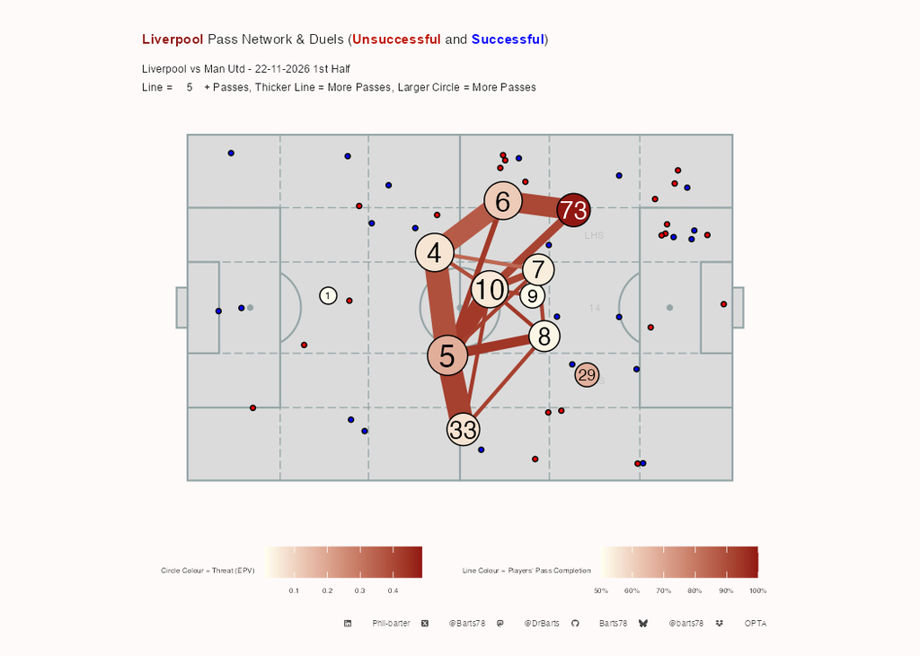

Away Pass Maps

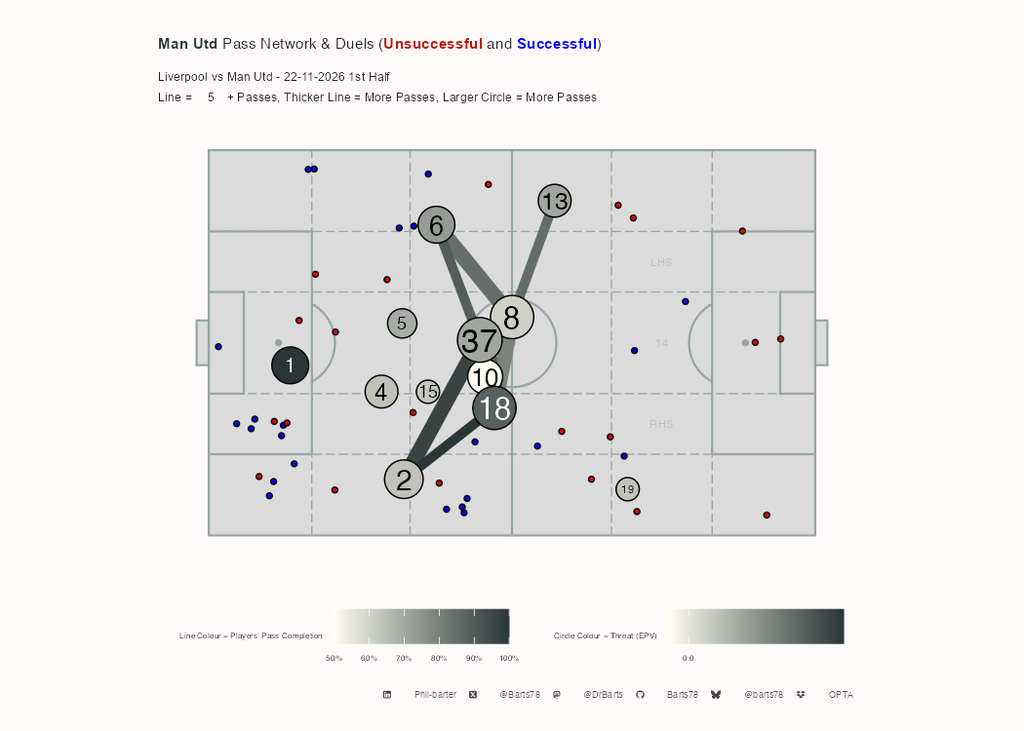

Home Pass Maps by Time

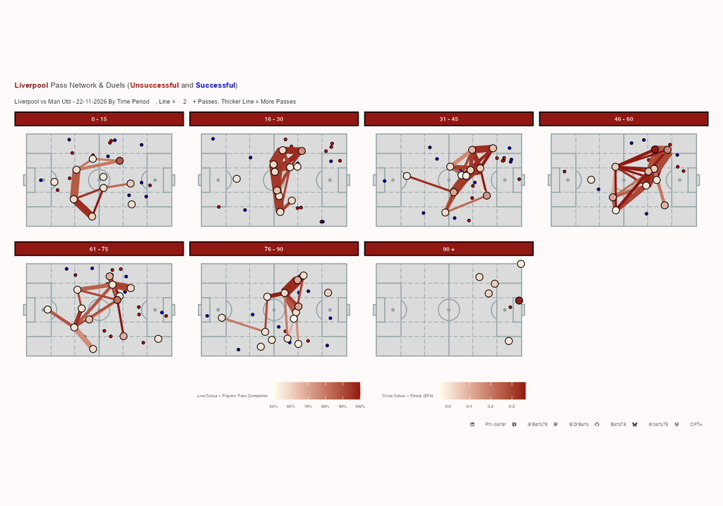

Away Pass Maps by Time

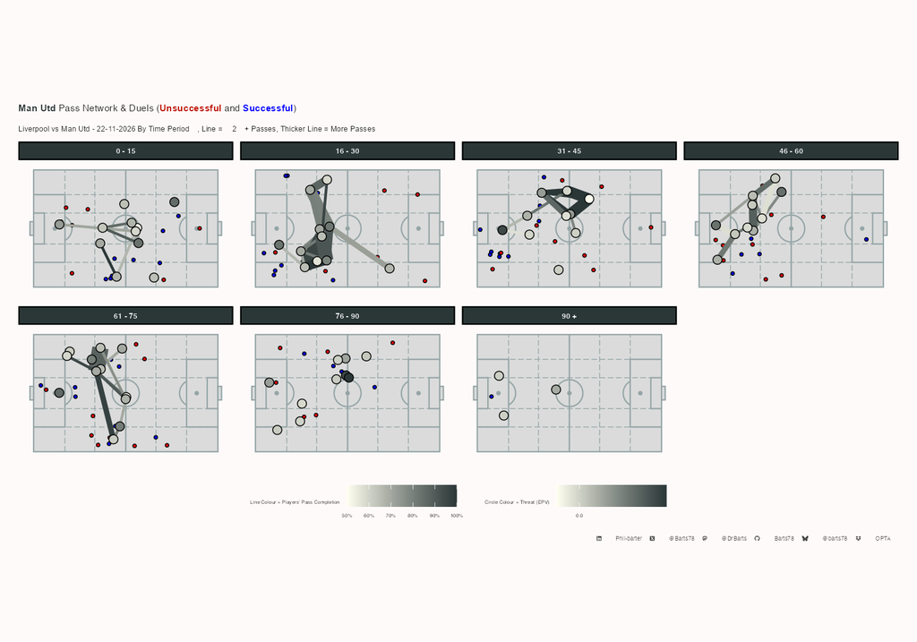

Home Attacking Pass Maps

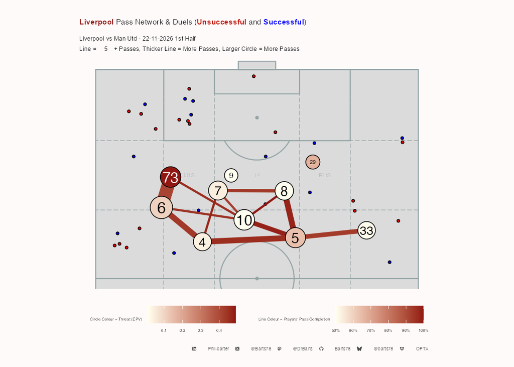

Away Attacking Pass Maps

[figure not shown]

Home Attacking Pass Maps by Time

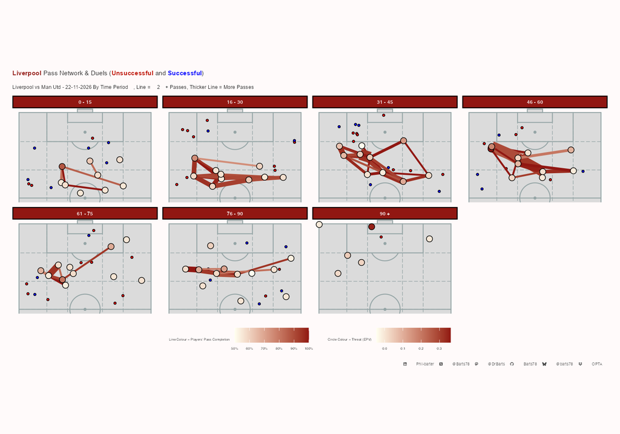

Away Attacking Pass Maps by Time

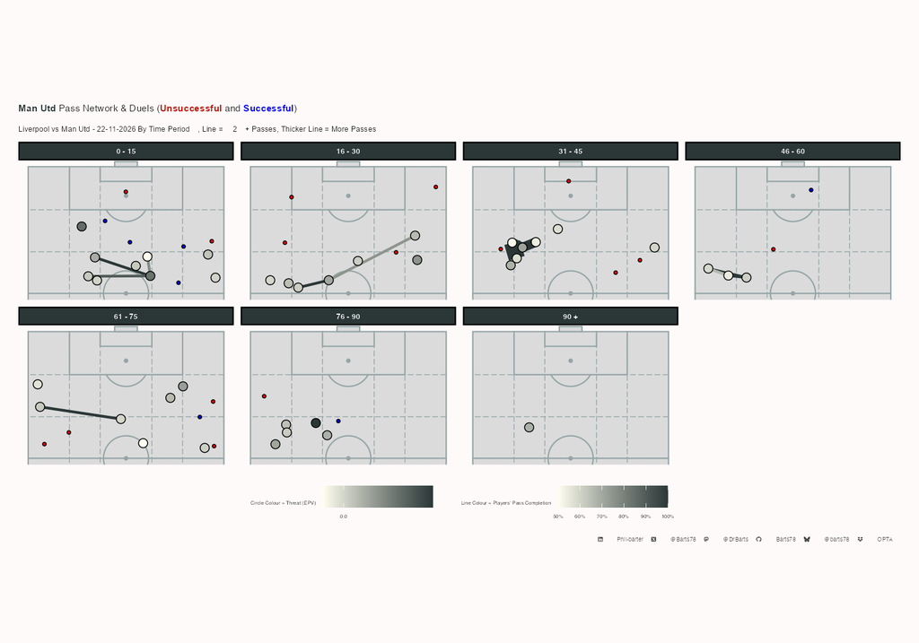

**Pass Connections by Passer**

Liverpool Open Play Passing connections

Liverpool vs Man Utd - 22-11-2026 | Completed passes only, min 5 per pair. Passer Completion % = all of the passer's attempts

|  | Completed Passes | % of Passer's Completions | % of Receiver's Receptions | Passer Completion % | Long Passes | Final Third Passes | PK Box Passes | Crosses | Key Passes | Prog Passes | EPV | EPV / Pass | Pass Time |
| --- | --- | --- | --- | --- | --- | --- | --- | --- | --- | --- | --- | --- | --- |
| Alexander Isak |  |  |  |  |  |  |  |  |  |  |  |  |  |
| Rio Ngumoha | 5 | 25% | 9% | 91% | 1 | 3 | 0 | 0 | 0 | 0 | 0.026 | 0.005 | 4.80 |
| Alexis Mac Allister |  |  |  |  |  |  |  |  |  |  |  |  |  |
| Dominik Szoboszlai | 8 | 16% | 11% | 89% | 0 | 4 | 0 | 0 | 1 | 0 | 0.008 | 0.001 | 2.88 |
| Florian Wirtz | 5 | 10% | 9% | 89% | 0 | 1 | 0 | 0 | 0 | 2 | 0.027 | 0.005 | 1.80 |
| Jérémy Jacquet | 11 | 22% | 19% | 89% | 0 | 5 | 0 | 0 | 0 | 0 | 0.046 | 0.004 | 1.91 |
| Ronald Araujo | 9 | 18% | 28% | 89% | 0 | 2 | 0 | 0 | 0 | 0 | 0.023 | 0.003 | 3.67 |
| Virgil van Dijk | 5 | 10% | 13% | 89% | 0 | 1 | 0 | 0 | 0 | 0 | 0.020 | 0.004 | 2.60 |
| Dominik Szoboszlai |  |  |  |  |  |  |  |  |  |  |  |  |  |
| Alexis Mac Allister | 11 | 14% | 25% | 95% | 0 | 8 | 0 | 0 | 1 | 0 | 0.023 | 0.002 | 2.64 |
| Bradley Barcola | 5 | 6% | 21% | 95% | 1 | 4 | 0 | 0 | 0 | 1 | 0.061 | 0.012 | 2.20 |
| Florian Wirtz | 16 | 21% | 28% | 95% | 0 | 10 | 0 | 0 | 0 | 2 | 0.098 | 0.006 | 2.12 |
| Jérémy Jacquet | 7 | 9% | 12% | 95% | 0 | 2 | 0 | 0 | 0 | 0 | 0.019 | 0.003 | 3.14 |
| Milos Kerkez | 9 | 12% | 16% | 95% | 0 | 6 | 0 | 0 | 0 | 2 | 0.043 | 0.005 | 2.11 |
| Rio Ngumoha | 14 | 18% | 25% | 95% | 1 | 11 | 0 | 0 | 1 | 0 | 0.047 | 0.003 | 2.86 |
| Trey Nyoni | 5 | 6% | 24% | 95% | 0 | 2 | 0 | 0 | 0 | 1 | 0.018 | 0.004 | 3.00 |
| Florian Wirtz |  |  |  |  |  |  |  |  |  |  |  |  |  |
| Alexander Isak | 6 | 10% | 25% | 90% | 1 | 1 | 0 | 0 | 2 | 4 | 0.092 | 0.015 | 2.17 |
| Alexis Mac Allister | 7 | 12% | 16% | 90% | 0 | 4 | 0 | 0 | 0 | 0 | 0.022 | 0.003 | 1.71 |
| Bradley Barcola | 6 | 10% | 25% | 90% | 0 | 6 | 0 | 0 | 3 | 4 | 0.288 | 0.048 | 2.67 |
| Dominik Szoboszlai | 15 | 26% | 21% | 90% | 0 | 12 | 1 | 0 | 2 | 1 | 0.071 | 0.005 | 2.00 |
| Rio Ngumoha | 6 | 10% | 10% | 90% | 1 | 4 | 0 | 0 | 1 | 1 | 0.042 | 0.007 | 5.17 |
| Jérémy Jacquet |  |  |  |  |  |  |  |  |  |  |  |  |  |
| Alexis Mac Allister | 9 | 15% | 20% | 87% | 0 | 0 | 0 | 0 | 0 | 2 | 0.026 | 0.003 | 2.44 |
| Alisson Becker | 6 | 10% | 75% | 87% | 0 | 0 | 0 | 0 | 0 | 0 | 0.016 | 0.003 | 2.50 |
| Dominik Szoboszlai | 7 | 12% | 10% | 87% | 0 | 1 | 0 | 0 | 0 | 3 | 0.023 | 0.003 | 3.71 |
| Milos Kerkez | 6 | 10% | 11% | 87% | 0 | 1 | 0 | 0 | 0 | 0 | 0.007 | 0.001 | 2.83 |
| Ronald Araujo | 12 | 20% | 38% | 87% | 0 | 0 | 0 | 0 | 0 | 0 | 0.013 | 0.001 | 2.58 |
| Virgil van Dijk | 14 | 24% | 36% | 87% | 0 | 2 | 0 | 0 | 0 | 0 | 0.014 | 0.001 | 3.00 |
| Milos Kerkez |  |  |  |  |  |  |  |  |  |  |  |  |  |
| Dominik Szoboszlai | 9 | 14% | 13% | 91% | 0 | 7 | 0 | 0 | 0 | 0 | 0.058 | 0.006 | 3.11 |
| Florian Wirtz | 9 | 14% | 16% | 91% | 0 | 4 | 0 | 0 | 0 | 0 | 0.041 | 0.005 | 3.33 |
| Rio Ngumoha | 23 | 37% | 40% | 91% | 0 | 11 | 0 | 0 | 0 | 2 | 0.113 | 0.005 | 4.61 |
| Virgil van Dijk | 7 | 11% | 18% | 91% | 0 | 1 | 0 | 0 | 0 | 0 | 0.011 | 0.002 | 3.29 |
| Víctor Muñoz | 5 | 8% | 42% | 91% | 0 | 3 | 0 | 0 | 0 | 0 | 0.022 | 0.004 | 2.40 |
| Rio Ngumoha |  |  |  |  |  |  |  |  |  |  |  |  |  |
| Alexis Mac Allister | 5 | 12% | 11% | 89% | 0 | 3 | 0 | 0 | 0 | 2 | 0.024 | 0.005 | 1.80 |
| Dominik Szoboszlai | 11 | 26% | 16% | 89% | 0 | 8 | 1 | 0 | 0 | 5 | 0.030 | 0.003 | 1.64 |
| Milos Kerkez | 13 | 31% | 23% | 89% | 0 | 10 | 1 | 0 | 0 | 4 | 0.155 | 0.012 | 1.77 |
| Ronald Araujo |  |  |  |  |  |  |  |  |  |  |  |  |  |
| Bradley Barcola | 7 | 19% | 29% | 84% | 0 | 1 | 0 | 0 | 0 | 0 | 0.041 | 0.006 | 1.86 |
| Jérémy Jacquet | 16 | 43% | 28% | 84% | 0 | 2 | 0 | 0 | 0 | 0 | 0.027 | 0.002 | 3.12 |
| Trey Nyoni |  |  |  |  |  |  |  |  |  |  |  |  |  |
| Florian Wirtz | 5 | 22% | 9% | 96% | 0 | 4 | 0 | 0 | 1 | 1 | 0.022 | 0.004 | 3.00 |
| Víctor Muñoz | 6 | 26% | 50% | 96% | 1 | 1 | 0 | 0 | 0 | 0 | 0.014 | 0.002 | 3.50 |
| Virgil van Dijk |  |  |  |  |  |  |  |  |  |  |  |  |  |
| Dominik Szoboszlai | 6 | 12% | 8% | 86% | 0 | 1 | 0 | 0 | 0 | 1 | 0.025 | 0.004 | 2.67 |
| Florian Wirtz | 5 | 10% | 9% | 86% | 0 | 0 | 0 | 0 | 0 | 1 | 0.026 | 0.005 | 2.40 |
| Jérémy Jacquet | 9 | 18% | 16% | 86% | 0 | 0 | 0 | 0 | 0 | 0 | 0.010 | 0.001 | 3.00 |
| Milos Kerkez | 12 | 24% | 21% | 86% | 0 | 1 | 0 | 0 | 0 | 0 | 0.026 | 0.002 | 2.33 |
| Rio Ngumoha | 5 | 10% | 9% | 86% | 0 | 1 | 0 | 0 | 0 | 1 | 0.026 | 0.005 | 2.40 |
| Víctor Muñoz |  |  |  |  |  |  |  |  |  |  |  |  |  |
| Trey Nyoni | 5 | 42% | 24% | 92% | 0 | 1 | 0 | 0 | 0 | 1 | 0.007 | 0.001 | 1.00 |

X @Barts78 · Bluesky @barts78 · Mastodon @DrBarts · GitHub Barts78 · LinkedIn Phil-barter · Data: Opta

**Pass Connections by Receiver**

Liverpool Open Play Passing connections

Liverpool vs Man Utd - 22-11-2026 | Completed passes only, min 5 per pair. Passer Completion % = all of the passer's attempts

|  | Completed Passes | % of Passer's Completions | % of Receiver's Receptions | Passer Completion % | Long Passes | Final Third Passes | PK Box Passes | Crosses | Key Passes | Prog Passes | EPV | EPV / Pass | Pass Time |
| --- | --- | --- | --- | --- | --- | --- | --- | --- | --- | --- | --- | --- | --- |
| Rio Ngumoha |  |  |  |  |  |  |  |  |  |  |  |  |  |
| Alexander Isak | 5 | 25% | 9% | 91% | 1 | 3 | 0 | 0 | 0 | 0 | 0.026 | 0.005 | 4.80 |
| Dominik Szoboszlai | 14 | 18% | 25% | 95% | 1 | 11 | 0 | 0 | 1 | 0 | 0.047 | 0.003 | 2.86 |
| Florian Wirtz | 6 | 10% | 10% | 90% | 1 | 4 | 0 | 0 | 1 | 1 | 0.042 | 0.007 | 5.17 |
| Milos Kerkez | 23 | 37% | 40% | 91% | 0 | 11 | 0 | 0 | 0 | 2 | 0.113 | 0.005 | 4.61 |
| Virgil van Dijk | 5 | 10% | 9% | 86% | 0 | 1 | 0 | 0 | 0 | 1 | 0.026 | 0.005 | 2.40 |
| Dominik Szoboszlai |  |  |  |  |  |  |  |  |  |  |  |  |  |
| Alexis Mac Allister | 8 | 16% | 11% | 89% | 0 | 4 | 0 | 0 | 1 | 0 | 0.008 | 0.001 | 2.88 |
| Florian Wirtz | 15 | 26% | 21% | 90% | 0 | 12 | 1 | 0 | 2 | 1 | 0.071 | 0.005 | 2.00 |
| Jérémy Jacquet | 7 | 12% | 10% | 87% | 0 | 1 | 0 | 0 | 0 | 3 | 0.023 | 0.003 | 3.71 |
| Milos Kerkez | 9 | 14% | 13% | 91% | 0 | 7 | 0 | 0 | 0 | 0 | 0.058 | 0.006 | 3.11 |
| Rio Ngumoha | 11 | 26% | 16% | 89% | 0 | 8 | 1 | 0 | 0 | 5 | 0.030 | 0.003 | 1.64 |
| Virgil van Dijk | 6 | 12% | 8% | 86% | 0 | 1 | 0 | 0 | 0 | 1 | 0.025 | 0.004 | 2.67 |
| Florian Wirtz |  |  |  |  |  |  |  |  |  |  |  |  |  |
| Alexis Mac Allister | 5 | 10% | 9% | 89% | 0 | 1 | 0 | 0 | 0 | 2 | 0.027 | 0.005 | 1.80 |
| Dominik Szoboszlai | 16 | 21% | 28% | 95% | 0 | 10 | 0 | 0 | 0 | 2 | 0.098 | 0.006 | 2.12 |
| Milos Kerkez | 9 | 14% | 16% | 91% | 0 | 4 | 0 | 0 | 0 | 0 | 0.041 | 0.005 | 3.33 |
| Trey Nyoni | 5 | 22% | 9% | 96% | 0 | 4 | 0 | 0 | 1 | 1 | 0.022 | 0.004 | 3.00 |
| Virgil van Dijk | 5 | 10% | 9% | 86% | 0 | 0 | 0 | 0 | 0 | 1 | 0.026 | 0.005 | 2.40 |
| Jérémy Jacquet |  |  |  |  |  |  |  |  |  |  |  |  |  |
| Alexis Mac Allister | 11 | 22% | 19% | 89% | 0 | 5 | 0 | 0 | 0 | 0 | 0.046 | 0.004 | 1.91 |
| Dominik Szoboszlai | 7 | 9% | 12% | 95% | 0 | 2 | 0 | 0 | 0 | 0 | 0.019 | 0.003 | 3.14 |
| Ronald Araujo | 16 | 43% | 28% | 84% | 0 | 2 | 0 | 0 | 0 | 0 | 0.027 | 0.002 | 3.12 |
| Virgil van Dijk | 9 | 18% | 16% | 86% | 0 | 0 | 0 | 0 | 0 | 0 | 0.010 | 0.001 | 3.00 |
| Ronald Araujo |  |  |  |  |  |  |  |  |  |  |  |  |  |
| Alexis Mac Allister | 9 | 18% | 28% | 89% | 0 | 2 | 0 | 0 | 0 | 0 | 0.023 | 0.003 | 3.67 |
| Jérémy Jacquet | 12 | 20% | 38% | 87% | 0 | 0 | 0 | 0 | 0 | 0 | 0.013 | 0.001 | 2.58 |
| Virgil van Dijk |  |  |  |  |  |  |  |  |  |  |  |  |  |
| Alexis Mac Allister | 5 | 10% | 13% | 89% | 0 | 1 | 0 | 0 | 0 | 0 | 0.020 | 0.004 | 2.60 |
| Jérémy Jacquet | 14 | 24% | 36% | 87% | 0 | 2 | 0 | 0 | 0 | 0 | 0.014 | 0.001 | 3.00 |
| Milos Kerkez | 7 | 11% | 18% | 91% | 0 | 1 | 0 | 0 | 0 | 0 | 0.011 | 0.002 | 3.29 |
| Alexis Mac Allister |  |  |  |  |  |  |  |  |  |  |  |  |  |
| Dominik Szoboszlai | 11 | 14% | 25% | 95% | 0 | 8 | 0 | 0 | 1 | 0 | 0.023 | 0.002 | 2.64 |
| Florian Wirtz | 7 | 12% | 16% | 90% | 0 | 4 | 0 | 0 | 0 | 0 | 0.022 | 0.003 | 1.71 |
| Jérémy Jacquet | 9 | 15% | 20% | 87% | 0 | 0 | 0 | 0 | 0 | 2 | 0.026 | 0.003 | 2.44 |
| Rio Ngumoha | 5 | 12% | 11% | 89% | 0 | 3 | 0 | 0 | 0 | 2 | 0.024 | 0.005 | 1.80 |
| Bradley Barcola |  |  |  |  |  |  |  |  |  |  |  |  |  |
| Dominik Szoboszlai | 5 | 6% | 21% | 95% | 1 | 4 | 0 | 0 | 0 | 1 | 0.061 | 0.012 | 2.20 |
| Florian Wirtz | 6 | 10% | 25% | 90% | 0 | 6 | 0 | 0 | 3 | 4 | 0.288 | 0.048 | 2.67 |
| Ronald Araujo | 7 | 19% | 29% | 84% | 0 | 1 | 0 | 0 | 0 | 0 | 0.041 | 0.006 | 1.86 |
| Milos Kerkez |  |  |  |  |  |  |  |  |  |  |  |  |  |
| Dominik Szoboszlai | 9 | 12% | 16% | 95% | 0 | 6 | 0 | 0 | 0 | 2 | 0.043 | 0.005 | 2.11 |
| Jérémy Jacquet | 6 | 10% | 11% | 87% | 0 | 1 | 0 | 0 | 0 | 0 | 0.007 | 0.001 | 2.83 |
| Rio Ngumoha | 13 | 31% | 23% | 89% | 0 | 10 | 1 | 0 | 0 | 4 | 0.155 | 0.012 | 1.77 |
| Virgil van Dijk | 12 | 24% | 21% | 86% | 0 | 1 | 0 | 0 | 0 | 0 | 0.026 | 0.002 | 2.33 |
| Trey Nyoni |  |  |  |  |  |  |  |  |  |  |  |  |  |
| Dominik Szoboszlai | 5 | 6% | 24% | 95% | 0 | 2 | 0 | 0 | 0 | 1 | 0.018 | 0.004 | 3.00 |
| Víctor Muñoz | 5 | 42% | 24% | 92% | 0 | 1 | 0 | 0 | 0 | 1 | 0.007 | 0.001 | 1.00 |
| Alexander Isak |  |  |  |  |  |  |  |  |  |  |  |  |  |
| Florian Wirtz | 6 | 10% | 25% | 90% | 1 | 1 | 0 | 0 | 2 | 4 | 0.092 | 0.015 | 2.17 |
| Alisson Becker |  |  |  |  |  |  |  |  |  |  |  |  |  |
| Jérémy Jacquet | 6 | 10% | 75% | 87% | 0 | 0 | 0 | 0 | 0 | 0 | 0.016 | 0.003 | 2.50 |
| Víctor Muñoz |  |  |  |  |  |  |  |  |  |  |  |  |  |
| Milos Kerkez | 5 | 8% | 42% | 91% | 0 | 3 | 0 | 0 | 0 | 0 | 0.022 | 0.004 | 2.40 |
| Trey Nyoni | 6 | 26% | 50% | 96% | 1 | 1 | 0 | 0 | 0 | 0 | 0.014 | 0.002 | 3.50 |

X @Barts78 · Bluesky @barts78 · Mastodon @DrBarts · GitHub Barts78 · LinkedIn Phil-barter · Data: Opta

**Away Pass Connections by Passer**

Man Utd Open Play Passing connections

Liverpool vs Man Utd - 22-11-2026 | Completed passes only, min 5 per pair. Passer Completion % = all of the passer's attempts

|  | Completed Passes | % of Passer's Completions | % of Receiver's Receptions | Passer Completion % | Long Passes | Final Third Passes | PK Box Passes | Crosses | Key Passes | Prog Passes | EPV | EPV / Pass | Pass Time |
| --- | --- | --- | --- | --- | --- | --- | --- | --- | --- | --- | --- | --- | --- |
| Bruno Fernandes |  |  |  |  |  |  |  |  |  |  |  |  |  |
| Patrick Dorgu | 8 | 31% | 33% | 76% | 1 | 0 | 0 | 0 | 0 | 1 | 0.029 | 0.004 | 4.50 |
| Diogo Dalot |  |  |  |  |  |  |  |  |  |  |  |  |  |
| Kobbie Mainoo | 9 | 32% | 21% | 93% | 0 | 0 | 0 | 0 | 0 | 0 | 0.011 | 0.001 | 2.22 |
| Youri Tielemans | 9 | 32% | 35% | 93% | 0 | 0 | 0 | 0 | 0 | 0 | 0.011 | 0.001 | 1.89 |
| Kobbie Mainoo |  |  |  |  |  |  |  |  |  |  |  |  |  |
| Bruno Fernandes | 7 | 16% | 21% | 90% | 0 | 1 | 0 | 0 | 0 | 0 | 0.015 | 0.002 | 1.71 |
| Diogo Dalot | 5 | 11% | 26% | 90% | 0 | 0 | 0 | 0 | 0 | 0 | 0.007 | 0.001 | 2.20 |
| Lisandro Martínez | 6 | 13% | 27% | 90% | 0 | 0 | 0 | 0 | 0 | 0 | 0.005 | 0.001 | 2.67 |
| Youri Tielemans | 9 | 20% | 35% | 90% | 1 | 1 | 0 | 0 | 1 | 0 | 0.013 | 0.001 | 2.56 |
| Lisandro Martínez |  |  |  |  |  |  |  |  |  |  |  |  |  |
| Bruno Fernandes | 6 | 18% | 18% | 92% | 1 | 0 | 0 | 0 | 0 | 0 | 0.023 | 0.004 | 2.00 |
| Kobbie Mainoo | 8 | 24% | 19% | 92% | 1 | 1 | 0 | 0 | 0 | 0 | 0.011 | 0.001 | 2.62 |
| Patrick Dorgu | 5 | 15% | 21% | 92% | 0 | 0 | 0 | 0 | 0 | 0 | 0.017 | 0.003 | 3.00 |
| Matthijs de Ligt |  |  |  |  |  |  |  |  |  |  |  |  |  |
| Diogo Dalot | 5 | 26% | 26% | 79% | 0 | 0 | 0 | 0 | 0 | 0 | 0.006 | 0.001 | 2.00 |
| Patrick Dorgu |  |  |  |  |  |  |  |  |  |  |  |  |  |
| Lisandro Martínez | 5 | 28% | 23% | 82% | 0 | 0 | 0 | 0 | 0 | 0 | 0.005 | 0.001 | 1.60 |
| Senne Lammens |  |  |  |  |  |  |  |  |  |  |  |  |  |
| Matthijs de Ligt | 5 | 42% | 25% | 35% | 1 | 0 | 0 | 0 | 0 | 0 | 0.006 | 0.001 | 4.00 |
| Youri Tielemans |  |  |  |  |  |  |  |  |  |  |  |  |  |
| Bruno Fernandes | 8 | 35% | 24% | 82% | 0 | 3 | 0 | 0 | 1 | 2 | 0.028 | 0.004 | 1.88 |
| Kobbie Mainoo | 5 | 22% | 12% | 82% | 0 | 0 | 0 | 0 | 0 | 0 | 0.009 | 0.002 | 2.20 |

X @Barts78 · Bluesky @barts78 · Mastodon @DrBarts · GitHub Barts78 · LinkedIn Phil-barter · Data: Opta

**Away Pass Connections by Receiver**

Man Utd Open Play Passing connections

Liverpool vs Man Utd - 22-11-2026 | Completed passes only, min 5 per pair. Passer Completion % = all of the passer's attempts

|  | Completed Passes | % of Passer's Completions | % of Receiver's Receptions | Passer Completion % | Long Passes | Final Third Passes | PK Box Passes | Crosses | Key Passes | Prog Passes | EPV | EPV / Pass | Pass Time |
| --- | --- | --- | --- | --- | --- | --- | --- | --- | --- | --- | --- | --- | --- |
| Patrick Dorgu |  |  |  |  |  |  |  |  |  |  |  |  |  |
| Bruno Fernandes | 8 | 31% | 33% | 76% | 1 | 0 | 0 | 0 | 0 | 1 | 0.029 | 0.004 | 4.50 |
| Lisandro Martínez | 5 | 15% | 21% | 92% | 0 | 0 | 0 | 0 | 0 | 0 | 0.017 | 0.003 | 3.00 |
| Kobbie Mainoo |  |  |  |  |  |  |  |  |  |  |  |  |  |
| Diogo Dalot | 9 | 32% | 21% | 93% | 0 | 0 | 0 | 0 | 0 | 0 | 0.011 | 0.001 | 2.22 |
| Lisandro Martínez | 8 | 24% | 19% | 92% | 1 | 1 | 0 | 0 | 0 | 0 | 0.011 | 0.001 | 2.62 |
| Youri Tielemans | 5 | 22% | 12% | 82% | 0 | 0 | 0 | 0 | 0 | 0 | 0.009 | 0.002 | 2.20 |
| Youri Tielemans |  |  |  |  |  |  |  |  |  |  |  |  |  |
| Diogo Dalot | 9 | 32% | 35% | 93% | 0 | 0 | 0 | 0 | 0 | 0 | 0.011 | 0.001 | 1.89 |
| Kobbie Mainoo | 9 | 20% | 35% | 90% | 1 | 1 | 0 | 0 | 1 | 0 | 0.013 | 0.001 | 2.56 |
| Bruno Fernandes |  |  |  |  |  |  |  |  |  |  |  |  |  |
| Kobbie Mainoo | 7 | 16% | 21% | 90% | 0 | 1 | 0 | 0 | 0 | 0 | 0.015 | 0.002 | 1.71 |
| Lisandro Martínez | 6 | 18% | 18% | 92% | 1 | 0 | 0 | 0 | 0 | 0 | 0.023 | 0.004 | 2.00 |
| Youri Tielemans | 8 | 35% | 24% | 82% | 0 | 3 | 0 | 0 | 1 | 2 | 0.028 | 0.004 | 1.88 |
| Diogo Dalot |  |  |  |  |  |  |  |  |  |  |  |  |  |
| Kobbie Mainoo | 5 | 11% | 26% | 90% | 0 | 0 | 0 | 0 | 0 | 0 | 0.007 | 0.001 | 2.20 |
| Matthijs de Ligt | 5 | 26% | 26% | 79% | 0 | 0 | 0 | 0 | 0 | 0 | 0.006 | 0.001 | 2.00 |
| Lisandro Martínez |  |  |  |  |  |  |  |  |  |  |  |  |  |
| Kobbie Mainoo | 6 | 13% | 27% | 90% | 0 | 0 | 0 | 0 | 0 | 0 | 0.005 | 0.001 | 2.67 |
| Patrick Dorgu | 5 | 28% | 23% | 82% | 0 | 0 | 0 | 0 | 0 | 0 | 0.005 | 0.001 | 1.60 |
| Matthijs de Ligt |  |  |  |  |  |  |  |  |  |  |  |  |  |
| Senne Lammens | 5 | 42% | 25% | 35% | 1 | 0 | 0 | 0 | 0 | 0 | 0.006 | 0.001 | 4.00 |

X @Barts78 · Bluesky @barts78 · Mastodon @DrBarts · GitHub Barts78 · LinkedIn Phil-barter · Data: Opta

Home Passing Tree Plot

[figure not shown]

Away Passing Tree Plot

[figure not shown]

Home wave plot

[figure not shown]

Away wave plot

[figure not shown]

**Home 1st Half Pass receiving Areas**

[figure not shown]

**Home 2nd Half Pass receiving Areas**

[figure not shown]

**Home Up to 1st Sub Pass receiving Areas**

[figure not shown]

**Away 1st Half Pass receiving Areas**

[figure not shown]

**Away 2nd Half Pass receiving Areas**

[figure not shown]

**Away Up to 1st Sub Pass receiving Areas**

[figure not shown]

Home Passing chains

[figure not shown]

Away Passing Chains

[figure not shown]

**Full time**

Liverpool FT Passing Chain Length (5, 6-10, 11-15, 16 +) & Distance (m)

Liverpool vs Man Utd - 22-11-2026

|  | Pass Chain Length | Total Chain Passes | Max Chain Length | Average Chain Length | Percent of Teams Passes | Total Chain Distance | Max Chain Distance | Average Chain Distance | Percent of Teams Passing Distance |
| --- | --- | --- | --- | --- | --- | --- | --- | --- | --- |
|  | VLow | 213 | 5 | 3 | 40% | 3,133.09 | 116.43 | 14.70 | 40% |
|  | Low | 118 | 10 | 8 | 22% | 1,802.68 | 187.44 | 15.30 | 23% |
|  | Medium | 80 | 15 | 13 | 15% | 1,173.56 | 268.27 | 14.70 | 15% |
|  | High | 122 | 20 | 17 | 23% | 1,737.44 | 289.05 | 14.20 | 22% |
| Overall Totals | — | 533 | 50 | 41 | — | 7,847 | 861 | 59 | — |
| Overall Average | — | 133 | 12 | 10 | — | 1,962 | 215 | 15 | — |

X @Barts78 · Bluesky @barts78 · Mastodon @DrBarts · GitHub Barts78 · LinkedIn Phil-barter · Data: Opta

**1st Half**

Liverpool 1st Half Passing Chain Length (5, 6-10, 11-15, 16 +) & Distance (m)

Liverpool vs Man Utd - 22-11-2026

|  | Pass Chain Length | Total Chain Passes | Max Chain Length | Average Chain Length | Percent of Teams Passes | Total Chain Distance | Max Chain Distance | Average Chain Distance | Percent of Teams Passing Distance |
| --- | --- | --- | --- | --- | --- | --- | --- | --- | --- |
|  | VLow | 82 | 4 | 3 | 31% | 1,258.73 | 116.43 | 15.40 | 31% |
|  | Low | 77 | 10 | 8 | 29% | 1,193.97 | 173.25 | 15.50 | 30% |
|  | Medium | 52 | 15 | 13 | 20% | 761.14 | 255.99 | 14.60 | 19% |
|  | High | 55 | 20 | 18 | 21% | 791.70 | 289.05 | 14.40 | 20% |
| Overall Totals | — | 266 | 49 | 42 | — | 4,006 | 835 | 60 | — |
| Overall Average | — | 66 | 12 | 10 | — | 1,001 | 209 | 15 | — |

X @Barts78 · Bluesky @barts78 · Mastodon @DrBarts · GitHub Barts78 · LinkedIn Phil-barter · Data: Opta

**2nd Half**

Liverpool 2nd Half Passing Chain Length (5, 6-10, 11-15, 16 +) & Distance (m)

Liverpool vs Man Utd - 22-11-2026

|  | Pass Chain Length | Total Chain Passes | Max Chain Length | Average Chain Length | Percent of Teams Passes | Total Chain Distance | Max Chain Distance | Average Chain Distance | Percent of Teams Passing Distance |
| --- | --- | --- | --- | --- | --- | --- | --- | --- | --- |
|  | VLow | 131 | 5 | 3 | 49% | 1,874.36 | 113.77 | 14.30 | 49% |
|  | Low | 41 | 10 | 8 | 15% | 608.71 | 187.44 | 14.80 | 16% |
|  | Medium | 28 | 15 | 14 | 10% | 412.42 | 268.27 | 14.70 | 11% |
|  | High | 67 | 18 | 17 | 25% | 945.74 | 272.30 | 14.10 | 25% |
| Overall Totals | — | 267 | 48 | 42 | — | 3,841 | 842 | 58 | — |
| Overall Average | — | 67 | 12 | 10 | — | 960 | 210 | 14 | — |

X @Barts78 · Bluesky @barts78 · Mastodon @DrBarts · GitHub Barts78 · LinkedIn Phil-barter · Data: Opta

**Away Full time**

Man Utd FT Passing Chain Length (5, 6-10, 11-15, 16 +) & Distance (m)

Liverpool vs Man Utd - 22-11-2026

|  | Pass Chain Length | Total Chain Passes | Max Chain Length | Average Chain Length | Percent of Teams Passes | Total Chain Distance | Max Chain Distance | Average Chain Distance | Percent of Teams Passing Distance |
| --- | --- | --- | --- | --- | --- | --- | --- | --- | --- |
|  | VLow | 193 | 5 | 3 | 70% | 2,703.27 | 120.88 | 14.00 | 71% |
|  | Low | 35 | 8 | 7 | 13% | 490.02 | 133.96 | 14.00 | 13% |
|  | Medium | 48 | 13 | 12 | 17% | 623.27 | 187.56 | 13.00 | 16% |
| Overall Totals | — | 276 | 26 | 22 | — | 3,817 | 442 | 41 | — |
| Overall Average | — | 92 | 9 | 7 | — | 1,272 | 147 | 14 | — |

X @Barts78 · Bluesky @barts78 · Mastodon @DrBarts · GitHub Barts78 · LinkedIn Phil-barter · Data: Opta

**Away 1st Half**

Man Utd 1st Half Passing Chain Length (5, 6-10, 11-15, 16 +) & Distance (m)

Liverpool vs Man Utd - 22-11-2026

|  | Pass Chain Length | Total Chain Passes | Max Chain Length | Average Chain Length | Percent of Teams Passes | Total Chain Distance | Max Chain Distance | Average Chain Distance | Percent of Teams Passing Distance |
| --- | --- | --- | --- | --- | --- | --- | --- | --- | --- |
|  | VLow | 104 | 5 | 3 | 68% | 1,392.58 | 120.88 | 13.40 | 67% |
|  | Low | 13 | 7 | 7 | 8% | 190.70 | 133.96 | 14.70 | 9% |
|  | Medium | 37 | 13 | 12 | 24% | 488.61 | 187.56 | 13.20 | 24% |
| Overall Totals | — | 154 | 25 | 22 | — | 2,072 | 442 | 41 | — |
| Overall Average | — | 51 | 8 | 7 | — | 691 | 147 | 14 | — |

X @Barts78 · Bluesky @barts78 · Mastodon @DrBarts · GitHub Barts78 · LinkedIn Phil-barter · Data: Opta

**Away 2nd Half**

Man Utd 2nd Half Passing Chain Length (5, 6-10, 11-15, 16 +) & Distance (m)

Liverpool vs Man Utd - 22-11-2026

|  | Pass Chain Length | Total Chain Passes | Max Chain Length | Average Chain Length | Percent of Teams Passes | Total Chain Distance | Max Chain Distance | Average Chain Distance | Percent of Teams Passing Distance |
| --- | --- | --- | --- | --- | --- | --- | --- | --- | --- |
|  | VLow | 89 | 4 | 2 | 73% | 1,310.69 | 100.00 | 14.70 | 75% |
|  | Low | 22 | 8 | 7 | 18% | 299.32 | 122.26 | 13.60 | 17% |
|  | Medium | 11 | 11 | 11 | 9% | 134.66 | 134.66 | 12.20 | 8% |
| Overall Totals | — | 122 | 23 | 20 | — | 1,745 | 357 | 40 | — |
| Overall Average | — | 41 | 8 | 7 | — | 582 | 119 | 14 | — |

X @Barts78 · Bluesky @barts78 · Mastodon @DrBarts · GitHub Barts78 · LinkedIn Phil-barter · Data: Opta

**Home Z14 RS By Half**

[figure not shown]

**Home Z14 RS By Game Period**

[figure not shown]

**Away Z14 RS By Half**

[figure not shown]

**Away Z14 RS By Game Period**

[figure not shown]

**Home Long Passes By half**

[figure not shown]

**Home Long Passes By Game Period**

[figure not shown]

**Away Long Passes By Half**

[figure not shown]

**Away Long Passes By Game period**

[figure not shown]

Set-Piece Summary

**Set Pieces**

Liverpool vs Man Utd - 22-11-2026

|  | Liverpool | Man Utd |
| --- | --- | --- |
| Corners |  |  |
| Corners taken | 15 | 5 |
| Short | 7 | 1 |
| Direct | 8 | 4 |
| Direct - first contact won | 1 (12%) | 2 (50%) |
| Free kicks |  |  |
| Free kicks (passes) | 8 | 16 |
| Into final third / box | 3 | 4 |
| Into box | 1 | 0 |
| Throw-ins |  |  |
| Throw-ins | 15 | 13 |
| Retained (first touch) | 73% | 69% |
| Shots by situation |  |  |
| Open-play shots | 24 | 7 |
| Open-play xG | 3.96 | 0.56 |
| Open-play goals | 3 | 0 |
| Set-piece shots | 4 | 3 |
| Set-piece xG | 0.41 | 0.09 |
| Set-piece goals | 1 | 0 |
| Penalties | 0 | 0 |
| Penalty xG | 0.00 | 0.00 |
| Set-piece share of xG | 9% | 14% |

First contact: the team that touches the ball first after the delivery (aerial duels go to the winner). Throw-ins retained = first touch by the taking team.  
X @Barts78 · Bluesky @barts78 · Mastodon @DrBarts · GitHub Barts78 · LinkedIn Phil-barter · Data: Opta

**Corners**

[figure not shown]

**Free Kicks**

[figure not shown]

**Corners**

[figure not shown]

**Free Kicks**

[figure not shown]

**Sequence Map**

[figure not shown]

**Sequence Table**

**Liverpool - Shot-Creating Sequences**

Liverpool vs Man Utd - 22-11-2026

| Min | Shooter | Result | xG | Situation | Started by | Started from | Start zone | Passes | Duration (s) |
| --- | --- | --- | --- | --- | --- | --- | --- | --- | --- |
| 2' | Barcola | Blocked | 0.08 | Open play | Ngumoha | Open-play regain | Mid third, Left wing | 4 | 11 |
| 6' | Isak | Saved | 0.30 | Open play | Barcola | Open-play regain | Mid third, Right half-space | 0 | 5 |
| 7' | van Dijk | Saved | 0.02 | Set piece | Szoboszlai | Corner | Att third, Right wing | 1 | 1 |
| 10' | Szoboszlai | Goal | 0.17 | Set piece | Kerkez | Free kick | Mid third, Left wing | 6 | 179 |
| 13' | Wirtz | Goal | 0.32 | Open play | Jacquet | Open-play regain | Def third, Right wing | 4 | 15 |
| 16' | Isak | Saved | 0.19 | Open play | Isak | Open-play regain | Mid third, Left half-space | 1 | 8 |
| 21' | Isak | Blocked | 0.17 | Open play | Kerkez | Open-play regain | Def third, Left wing | 5 | 18 |
| 34' | Ngumoha | Off target | 0.03 | Open play | Mac Allister | Open-play regain | Mid third, Central | 0 | 4 |
| 39' | Mac Allister | Saved | 0.09 | Open play | Becker | Keeper | Def third, Central | 21 | 72 |
| 40' | Isak | Blocked | 0.21 | Open play | Szoboszlai | Open-play regain | Mid third, Central | 2 | 7 |
| 45' | Szoboszlai | Off target | 0.05 | Open play | Ngumoha | Open-play regain | Att third, Left half-space | 1 | 3 |
| 45+1' | Ngumoha | Blocked | 0.02 | Set piece | Wirtz | Corner | Att third, Left wing | 3 | 7 |
| 46' | Szoboszlai | Off target | 0.02 | Open play | Wirtz | Open-play regain | Mid third, Central | 5 | 11 |
| 48' | Szoboszlai | Saved | 0.03 | Open play | Kerkez | Open-play regain | Att third, Left wing | 1 | 4 |
| 61' | Mac Allister | Blocked | 0.03 | Open play | Araujo | Throw-in | Def third, Right wing | 6 | 18 |
| 62' | Isak | Off target | 0.21 | Open play | Araujo | Open-play regain | Mid third, Right wing | 3 | 6 |
| 64' | Ngumoha | Blocked | 0.03 | Open play | Jacquet | Open-play regain | Mid third, Right half-space | 2 | 7 |
| 65' | Barcola | Off target | 0.24 | Open play | Jacquet | Open-play regain | Mid third, Right half-space | 8 | 28 |
| 66' | Ngumoha | Goal | 0.63 | Open play | Mac Allister | Open-play regain | Def third, Right half-space | 2 | 11 |
| 68' | Barcola | Blocked | 0.39 | Open play | Mac Allister | Open-play regain | Def third, Left half-space | 3 | 14 |
| 75' | Isak | Saved | 0.24 | Open play | Nyoni | Open-play regain | Def third, Right half-space | 3 | 11 |
| 75' | Szoboszlai | Saved | 0.02 | Open play | Nyoni | Open-play regain | Def third, Right half-space | 4 | 22 |
| 76' | van Dijk | Off target | 0.20 | Set piece | Szoboszlai | Corner | Att third, Right wing | 3 | 10 |
| 77' | Nyoni | Off target | 0.05 | Open play | Nyoni | Open-play regain | Mid third, Left half-space | 15 | 40 |
| 82' | Muñoz | Goal | 0.53 | Open play | van Dijk | Open-play regain | Att third, Left half-space | 2 | 4 |
| 85' | Szoboszlai | Blocked | 0.03 | Open play | van Dijk | Open-play regain | Mid third, Central | 0 | 8 |
| 89' | Wirtz | Blocked | 0.04 | Open play | Kerkez | Open-play regain | Att third, Left wing | 4 | 11 |
| 90+1' | Szoboszlai | Blocked | 0.03 | Open play | Gomez | Free kick | Mid third, Right wing | 8 | 20 |

X @Barts78 · Bluesky @barts78 · Mastodon @DrBarts · GitHub Barts78 · LinkedIn Phil-barter · Data: Opta

**Sequence Map**

[figure not shown]

**Sequence Table**

**Man Utd - Shot-Creating Sequences**

Liverpool vs Man Utd - 22-11-2026

| Min | Shooter | Result | xG | Situation | Started by | Started from | Start zone | Passes | Duration (s) |
| --- | --- | --- | --- | --- | --- | --- | --- | --- | --- |
| 5' | Fernandes | Off target | 0.04 | Set piece | Mbeumo | Open-play regain | Mid third, Right wing | 1 | 62 |
| 12' | Mainoo | Off target | 0.01 | Open play | Dorgu | Throw-in | Att third, Left wing | 4 | 11 |
| 29' | Fernandes | Saved | 0.05 | Open play | Mainoo | Free kick | Def third, Left wing | 13 | 30 |
| 35' | Tielemans | Blocked | 0.02 | Open play | Fernandes | Open-play regain | Mid third, Central | 5 | 15 |
| 51' | Zirkzee | Blocked | 0.04 | Open play | Mainoo | Open-play regain | Def third, Central | 2 | 11 |
| 52' | de Ligt | Off target | 0.02 | Set piece | Fernandes | Corner | Att third, Right wing | 1 | 3 |
| 79' | Zirkzee | Off target | 0.12 | Open play | Martínez | Open-play regain | Mid third, Left half-space | 2 | 7 |
| 79' | Fernandes | Saved | 0.02 | Open play | Maguire | Open-play regain | Mid third, Central | 1 | 5 |
| 90+2' | Fernandes | Saved | 0.30 | Open play | Dalot | Open-play regain | Def third, Left half-space | 2 | 10 |
| 90+3' | Maguire | Off target | 0.03 | Set piece | Fernandes | Corner | Att third, Right wing | 1 | 1 |

X @Barts78 · Bluesky @barts78 · Mastodon @DrBarts · GitHub Barts78 · LinkedIn Phil-barter · Data: Opta

Entries by Channel

**Box and Final-Third Entries (open play)**

Liverpool vs Man Utd - 22-11-2026

|  | Box entries Passes | Box entries Carries | Box entries Total | Box entries Success % | Final-third entries Passes | Final-third entries Carries | Final-third entries Total | Final-third entries Success % |
| --- | --- | --- | --- | --- | --- | --- | --- | --- |
| Liverpool |  |  |  |  |  |  |  |  |
| Left wing | 13 | 4 | 17 | 65% | 16 | 5 | 21 | 100% |
| Left half-space | 8 | 5 | 13 | 77% | 12 | 6 | 18 | 89% |
| Central | 9 | 0 | 9 | 78% | 16 | 5 | 21 | 95% |
| Right half-space | 6 | 2 | 8 | 38% | 13 | 2 | 15 | 40% |
| Right wing | 3 | 2 | 5 | 20% | 11 | 5 | 16 | 50% |
| Total | 39 | 13 | 52 | 62% | 68 | 23 | 91 | 78% |
| Man Utd |  |  |  |  |  |  |  |  |
| Left wing | 5 | 0 | 5 | 20% | 5 | 3 | 8 | 62% |
| Left half-space | 1 | 0 | 1 | 100% | 4 | 2 | 6 | 67% |
| Central | 1 | 0 | 1 | 100% | 8 | 0 | 8 | 50% |
| Right half-space | 1 | 1 | 2 | 50% | 7 | 0 | 7 | 86% |
| Right wing | 2 | 1 | 3 | 0% | 2 | 2 | 4 | 25% |
| Total | 10 | 2 | 12 | 33% | 26 | 7 | 33 | 61% |

Channel = where the pass or carry started. Left/right from the attacking team's view. Set pieces excluded.  
X @Barts78 · Bluesky @barts78 · Mastodon @DrBarts · GitHub Barts78 · LinkedIn Phil-barter · Data: Opta

**Box**

[figure not shown]

**Final Third**

[figure not shown]

**Box**

[figure not shown]

**Final Third**

[figure not shown]

**Match Stats**

**Passing stats**

Liverpool vs Man Utd - 22-11-2026

|  | Name | Mins | % of Team Possession | xA | xT | Attempted Passes | Successful Passes | Pass Success % | Assists | BCs | Key Passes | Long Ps | Final 3rd P | Prog Ps | PK Box P | Pass Received | PPs Received | KPs Recieved | Recieveing Suc | EPV Recieved | EPV Created | % of Team EPV |
| --- | --- | --- | --- | --- | --- | --- | --- | --- | --- | --- | --- | --- | --- | --- | --- | --- | --- | --- | --- | --- | --- | --- |
| Keeper | Alisson Becker | 97 | 0.03 | 0 | 0 | 9 | 7 | 0.78 | 0 | 0 | 0 | 2 | 0 | 1 | 0 | 8 | 0 | 0 | 1 | 0.022 | 0.023 | 0.01 |
| Defender | Jérémy Jacquet | 97 | 0.1 | 0 | 0.12 | 68 | 59 | 0.87 | 0 | 0 | 0 | 4 | 6 | 9 | 0 | 68 | 1 | 0 | 0.867647058823529 | 0.233 | 0.2 | 0.05 |
| Defender | Milos Kerkez | 97 | 0.11 | 0 | 0.31 | 69 | 63 | 0.91 | 0 | 0 | 0 | 2 | 37 | 5 | 3 | 64 | 7 | 0 | 0.875 | 0.358 | 0.32 | 0.08 |
| Defender | Virgil van Dijk | 97 | 0.09 | 0.07 | 0.04 | 58 | 50 | 0.86 | 0 | 1 | 0 | 3 | 5 | 4 | 1 | 52 | 0 | 0 | 0.75 | 0.179 | 0.157 | 0.04 |
| Defender | Ronald Araujo | 89 | 0.08 | 0 | 0.12 | 44 | 37 | 0.84 | 0 | 0 | 0 | 6 | 8 | 3 | 1 | 43 | 0 | 0 | 0.744186046511628 | 0.146 | 0.155 | 0.04 |
| Defender | Joe Gomez | 8 | 0.01 | 0 | 0 | 3 | 2 | 0.67 | 0 | 0 | 0 | 1 | 0 | 1 | 0 | 2 | 0 | 0 | 0 | 0.023 | 0.008 | 0 |
| Midfielder | Dominik Szoboszlai | 97 | 0.14 | 0.12 | 0.3 | 81 | 77 | 0.95 | 0 | 0 | 3 | 2 | 50 | 6 | 0 | 79 | 12 | 5 | 0.89873417721519 | 0.363 | 0.431 | 0.1 |
| Midfielder | Florian Wirtz | 97 | 0.1 | 0.2 | 0.78 | 63 | 57 | 0.9 | 1 | 1 | 10 | 4 | 35 | 11 | 2 | 64 | 15 | 2 | 0.890625 | 0.634 | 0.895 | 0.22 |
| Midfielder | Rio Ngumoha | 82 | 0.1 | 0.24 | 0.85 | 47 | 42 | 0.89 | 1 | 1 | 4 | 1 | 35 | 18 | 8 | 60 | 5 | 3 | 0.95 | 0.374 | 0.885 | 0.22 |
| Midfielder | Alexis Mac Allister | 76 | 0.09 | 0 | 0.15 | 55 | 49 | 0.89 | 0 | 0 | 2 | 5 | 17 | 5 | 0 | 55 | 6 | 1 | 0.8 | 0.207 | 0.199 | 0.05 |

[output cut: 6 more lines]